# Figuras e simulaçã o

# Inference for two populations

Inference for two populations

## Used packages

```r
library(readxl)
library(readr)
library(openxlsx)
library(latex2exp)
library(xtable)
library(tidyverse)
```

## Normal distribution with normal distribution and known variances

We want to compare the means of two normal populations $N(\mu_1, \sigma_1^2)$ e $N(\mu_2, \sigma_2^2)$. Here, we illustrate the ideas of decision, the critical regions and the critical values.

### Bilateral

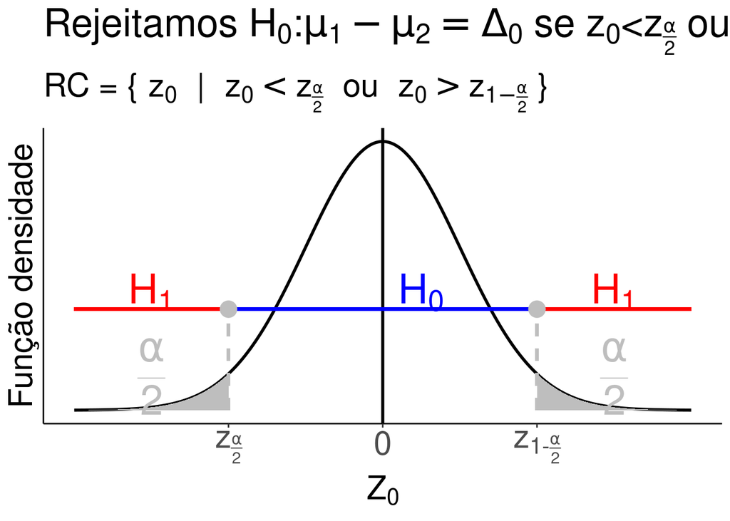

```r
z <- seq(from = -4, to= 4, by = 0.001)
f <- dnorm(z)
dados <- tibble(z=z, f=f)

ggplot(dados)+
  geom_line(aes(x = z, y = f), color = "black", size = 1) +
  labs(x = TeX("$Z_0$"), y = "Função densidade",
       title = TeX("Rejeitamos $H_0: \\mu_{1} - \\mu_{2} = \\Delta_{0}$ se $z_0 < z_{\\frac{\\alpha}{2}}$ ou $z_0 > z_{1-\\frac{\\alpha}{2}}$"),
       subtitle = bquote("RC = {" ~ z[0] ~ " | " ~ z[0] < z[frac(alpha, 2)] ~ " ou " ~ z[0] > z[1-frac(alpha, 2)] ~ "}")) +
  scale_x_continuous(breaks = c(-2, 0, 2),
                     labels = c(TeX("$z_{\\frac{\\alpha}{2}}$"), "0",
                                TeX("$z_{1- \\frac{\\alpha}{2}}$"))) +
  scale_y_continuous(breaks = NULL) +
  geom_ribbon(data = dplyr::filter(dados, z < -2),
              aes(x = z, y = f, ymin = 0, ymax = f),
              fill = "gray") +
  geom_ribbon(data = dplyr::filter(dados, z > 2),
              aes(x = z, y = f, ymin = 0, ymax = f),
              fill = "gray") +
  theme_classic() +
  theme(axis.title = element_text(size = 22.5),
        axis.text = element_text(size = 22.5),
        title = element_text(size = 22.5)) +
  geom_vline(xintercept = 0, color = "black", size = 1) +
  geom_segment(x = -4, xend = -2, y = 0.15, yend =0.15, size = 1, color = "red") +
  geom_segment(x = 2, xend = 4, y = 0.15, yend =0.15, size = 1, color = "red") +
  geom_segment(x = -2, xend = 2, y = 0.15, yend =0.15, size = 1, color = "blue") +
  geom_segment(x = -2, xend = -2, y = 0, yend = 0.15,
               linetype = "dashed", color = "gray", size = 1) +
  geom_segment(x = 2, xend = 2, y = 0, yend = 0.15,
               linetype = "dashed", color = "gray", size = 1) +
  geom_point(data = tibble(x = c(-2, 2), y = c(0.15, 0.15)),
             aes(x = x, y = y), size = 5,color  = "gray") +
  annotate("text", x = -3, y = 0.175, label = "H[1]",
           size = 10, color = "red", parse = T) +
  annotate("text", x = 3, y = 0.175, label = "H[1]",
           size = 10, color = "red", parse = T) +
  annotate("text", x = 0.5, y = 0.175, label = "H[0]",
           size = 10, color = "blue", parse = T) +
  annotate("text", x = -3, y = 0.05, label = "frac(alpha, 2)", parse = T,
           color = "gray", size = 10) +
  annotate("text", x = 3, y = 0.05, label = "frac(alpha, 2)", parse = T,
           color = "gray", size = 10)
```

```r
ggsave("../figures/2-pop-normal-s2-known-bilateral.png")
ggsave("../figures/2-pop-normal-s2-known-bilateral.pdf")
```

We will simulate an example. Simulated example.

```r
set.seed(1235813)
amostra1 <- rnorm(10, mean = 600, sd = 0.6) %>% round(2)
amostra2 <- rnorm(10, mean = 600, sd = 0.75) %>% round(2)

dados <- rbind(amostra1, amostra2)

dados %>% xtable(caption = "Amostras para as máquinas 1 e 2.",
                 label = "tab:volume-maquinas",
                 align = rep("c", ncol(dados) + 1),
                 digits = 2) %>%
  print.xtable(booktabs = T,
               format.args = list(decimal.mark = ','),
               include.colnames =  F)
```

```
% latex table generated in R 4.1.0 by xtable 1.8-4 package
% Sun May 30 15:08:17 2021
\begin{table}[ht]
\centering
\begin{tabular}{ccccccccccc}
  \toprule
  \midrule
amostra1 & 599,67 & 600,74 & 599,49 & 600,56 & 599,65 & 599,72 & 600,34 & 600,17 & 599,87 & 599,44 \\
  amostra2 & 600,18 & 599,66 & 600,36 & 601,47 & 600,57 & 602,25 & 601,19 & 601,07 & 600,81 & 599,26 \\
   \bottomrule
\end{tabular}
\caption{Amostras para as máquinas 1 e 2.}
\label{tab:volume-maquinas}
\end{table}
```

```r
rowMeans(dados)
```

```
amostra1 amostra2
 599.965  600.682
```

## Unilateral ($H_1$ lower)

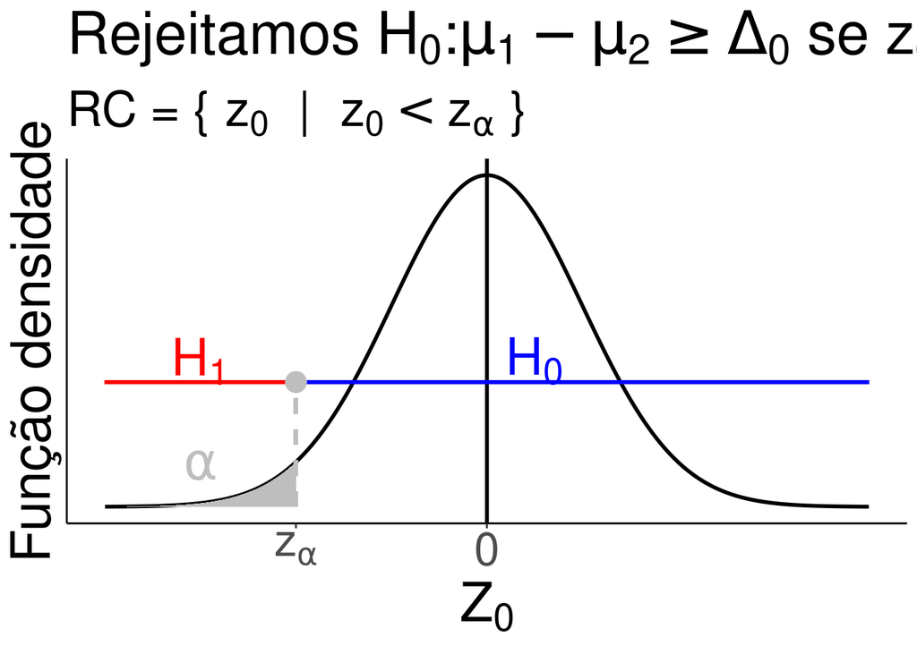

```r
z <- seq(from = -4, to= 4, by = 0.001)
f <- dnorm(z)
dados <- tibble(z=z, f=f)

ggplot(dados) +
  geom_line(aes(x = z, y = f), color = "black", size = 1) +
  labs(x = TeX("$Z_0$"), y = "Função densidade",
       title = TeX("Rejeitamos $H_0: \\mu_{1} - \\mu_{2} \\geq \\Delta_0$ se $z_0 < z_{\\alpha}$"),
       subtitle = bquote("RC = {" ~ z[0] ~ " | " ~ z[0] < z[alpha] ~ "}")) +
  scale_x_continuous(breaks = c(-2, 0),
                     labels = c(TeX("$z_{\\alpha}$"), "0")) +
  scale_y_continuous(breaks = NULL) +
  geom_ribbon(data = dplyr::filter(dados, z < -2),
              aes(x = z, y = f, ymin = 0, ymax = f),
              fill = "gray") +
  theme_classic() +
  theme(axis.title = element_text(size = 30),
        axis.text = element_text(size = 25),
        title = element_text(size = 27)) +
  geom_vline(xintercept = 0, color = "black", size = 1) +
  geom_segment(x = -4, xend = -2, y = 0.15, yend =0.15, size = 1, color = "red") +
  geom_segment(x = -2, xend = 4, y = 0.15, yend =0.15, size = 1, color = "blue") +
  geom_segment(x = -2, xend = -2, y = 0, yend = 0.15,
               linetype = "dashed", color = "gray", size = 1) +
  geom_point(data = tibble(x = c(-2), y = c(0.15)),
             aes(x = x, y = y), size = 5,color  = "gray") +
  annotate("text", x = -3, y = 0.175, label = "H[1]",
           size = 10, color = "red", parse = T) +
  annotate("text", x = 0.5, y = 0.175, label = "H[0]",
           size = 10, color = "blue", parse = T) +
  annotate("text", x = -3, y = 0.05, label = "alpha", parse = T,
           color = "gray", size = 10)
```

```r
ggsave("../figures/2-pop-normal-s2-known-h1-lower.png")
ggsave("../figures/2-pop-normal-s2-known-h1-lower.pdf")
```

Simulated example.

```r
set.seed(1235813)
amostra1 <- rnorm(10, mean = 50, sd = 8)
amostra2 <- rnorm(20, mean = 35, sd = 8)

mean(amostra1) %>% round(2)
```

```
[1] 49.53
```

```r
mean(amostra2) %>% round(2)
```

```
[1] 39.42
```

## Unilateral ($H_1$ upper)

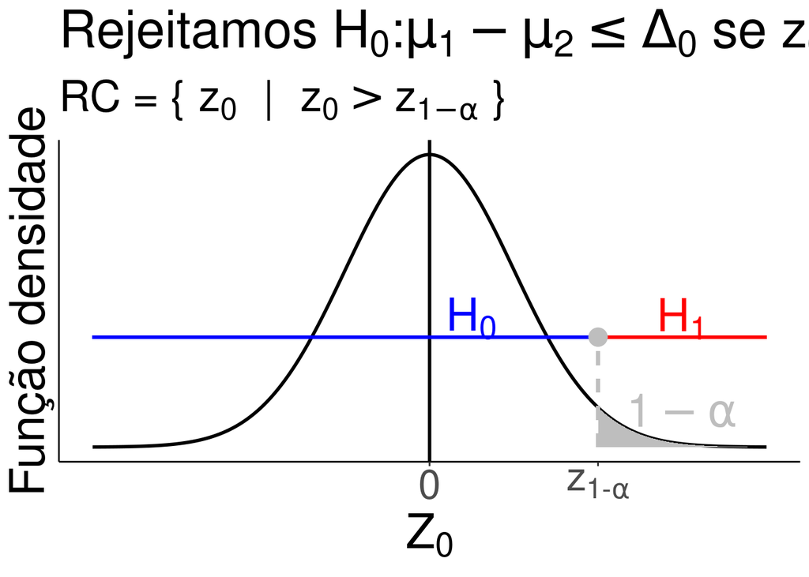

```r
z <- seq(from = -4, to= 4, by = 0.001)
f <- dnorm(z)
dados <- tibble(z=z, f=f)

ggplot(dados)+
  geom_line(aes(x = z, y = f), color = "black", size = 1) +
  labs(x = TeX("$Z_0$"), y = "Função densidade",
       title = TeX("Rejeitamos $H_0: \\mu_1 - \\mu_2 \\leq \\Delta_0$ se $z_0 > z_{1 - \\alpha}$"),
       subtitle = bquote("RC = {" ~ z[0] ~ " | " ~ z[0] > z[1-alpha] ~ "}")) +
  scale_x_continuous(breaks = c(0, 2),
                     labels = c("0", TeX("$z_{1- \\alpha}$"))) +
  scale_y_continuous(breaks = NULL) +
  geom_ribbon(data = dplyr::filter(dados, z > 2),
              aes(x = z, y = f, ymin = 0, ymax = f),
              fill = "gray") +
  theme_classic() +
  theme(axis.title = element_text(size = 30),
        axis.text = element_text(size = 25),
        title = element_text(size = 27)) +
  geom_vline(xintercept = 0, color = "black", size = 1) +
  geom_segment(x = 2, xend = 4, y = 0.15, yend =0.15, size = 1, color = "red") +
  geom_segment(x = -4, xend = 2, y = 0.15, yend =0.15, size = 1, color = "blue") +
  geom_segment(x = 2, xend = 2, y = 0, yend = 0.15,
               linetype = "dashed", color = "gray", size = 1) +
  geom_segment(x = 2, xend = 2, y = 0, yend = 0.15,
               linetype = "dashed", color = "gray", size = 1) +
  geom_point(data = tibble(x = c(2), y = c(0.15)),
             aes(x = x, y = y), size = 5,color  = "gray") +
  annotate("text", x = 3, y = 0.175, label = "H[1]",
           size = 10, color = "red", parse = T) +
  annotate("text", x = 0.5, y = 0.175, label = "H[0]",
           size = 10, color = "blue", parse = T) +
  annotate("text", x = 3, y = 0.05, label = "1-alpha", parse = T,
           color = "gray", size = 10)
```

```r
ggsave("../figures/2-pop-normal-s2-known-h1-upper.png")
ggsave("../figures/2-pop-normal-s2-known-h1-upper.pdf")
```

## test on variance for two normal populations

First we introduce the idea of F-Snedecor distribution. Should I create a table for my perspective? Yes, I did it.

Below we create graphs to illustrate the idea of decision.

## bilateral test on variance.

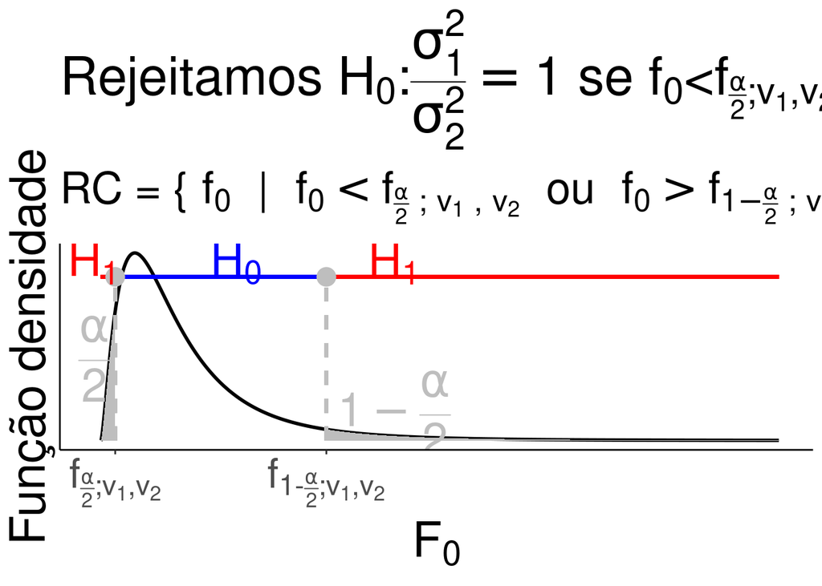

```r
v1 <- 5
v2 <- 10
xmax <- 10
z <- seq(from = 0, to= xmax, by = 0.001)
f <- df(z, df1 = v1, df2 = v2)
dados <- tibble(z=z, f=f)
a <- 0.1
lower <- qf(a / 2, df1 = v1, df2 = v2)
upper <- qf(1 - a / 2, df1 = v1, df2 = v2)


ggplot(dados)+
  geom_line(aes(x = z, y = f), color = "black", size = 1) +
  labs(x = TeX("$F_0$"), y = "Função densidade",
       title = TeX("Rejeitamos $H_0: \\frac{\\sigma_1^2}{\\sigma_2^2} = 1$ se $f_0 < f_{\\frac{\\alpha}{2};v_1, v_2}$ ou $f_0 > f_{\\frac{\\alpha}{2}; v_1, v_2}$"),
       subtitle = bquote("RC = {" ~ f[0] ~ " | " ~ f[0] < f[frac(alpha, 2)~';'~v[1]~','~v[2]] ~' ou '~f[0] > f[1-frac(alpha, 2)~';'~v[1]~','~v[2]]~ "}")) +
  scale_x_continuous(breaks = c(lower, upper),
                     labels = c(TeX("$f_{\\frac{\\alpha}{2};v_1, v_2}$"), TeX("$f_{1-\\frac{\\alpha}{2};v_1, v_2}$"))) +
  scale_y_continuous(breaks = NULL) +
  geom_ribbon(data = dplyr::filter(dados, z > upper),
              aes(x = z, y = f, ymin = 0, ymax = f),
              fill = "gray")+
  geom_ribbon(data = dplyr::filter(dados, z < lower),
              aes(x = z, y = f, ymin = 0, ymax = f),
              fill = "gray") +
  theme_classic() +
  theme(axis.title = element_text(size = 30),
        axis.text = element_text(size = 25),
        title = element_text(size = 27)) +
  geom_segment(x = 0, xend = lower, y = 0.6, yend =0.6, size = 1, color = "red") +
  geom_segment(x = upper, xend = xmax, y = 0.6, yend =0.6, size = 1, color = "red") +
  geom_segment(x = lower, xend = upper, y = 0.6, yend =0.6, size = 1, color = "blue") +
  geom_segment(x = lower, xend = lower, y = 0, yend = 0.6,
               linetype = "dashed", color = "gray", size = 1) +
  geom_segment(x = upper, xend = upper, y = 0, yend = 0.6,
               linetype = "dashed", color = "gray", size = 1) +
  geom_point(data = tibble(x = c(lower, upper), y = c(0.6, 0.6)),
             aes(x = x, y = y), size = 5,color  = "gray") +
  annotate("text", x = -0.1, y = 0.65, label = "H[1]",
           size = 10, color = "red", parse = T) +
  annotate("text", x = 2, y = 0.65, label = "H[0]",
           size = 10, color = "blue", parse = T) +
  annotate("text", x = upper+1, y = 0.65, label = "H[1]",
           size = 10, color = "red", parse = T) +
  annotate("text", x = -0.1, y = 0.30, label = "frac(alpha, 2)", parse = T,
           color = "gray", size = 10) +
  annotate("text", x = upper + 1, y = 0.10, label = "1-frac(alpha, 2)", parse = T,
           color = "gray", size = 10)
```

```r
ggsave("../figures/test-variance-bilateral.png", width = 10, height = 10)
ggsave("../figures/test-variance-bilateral.pdf", width = 10, height = 10)
```

Below we explain the p-value:

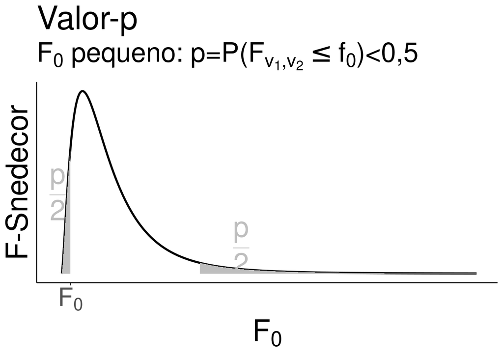

```r
v1 <- 5
v2 <- 10
xmax <- 10
z <- seq(from = 0, to= xmax, by = 0.001)
f <- df(z, df1 = v1, df2 = v2)
dados <- tibble(z=z, f=f)
a <- 0.1
lower <- qf(a / 2, df1 = v1, df2 = v2)
upper <- qf(1 - a / 2, df1 = v1, df2 = v2)


ggplot(dados)+
  geom_line(aes(x = z, y = f), color = "black", size = 1) +
  labs(x = TeX("$F_0$"), y = "F-Snedecor",
       title = "Valor-p",
       subtitle = TeX("$F_0$ pequeno: $p=P(F_{v_1, v_2} \\leq f_0) < 0,5$")) +
  scale_x_continuous(breaks = c(lower),
                     labels = c(TeX("$F_0$"))) +
  scale_y_continuous(breaks = NULL) +
  geom_ribbon(data = dplyr::filter(dados, z > upper),
              aes(x = z, y = f, ymin = 0, ymax = f),
              fill = "gray") +
  geom_ribbon(data = dplyr::filter(dados, z < lower),
              aes(x = z, y = f, ymin = 0, ymax = f),
              fill = "gray") +
  theme_classic() +
  theme(axis.title = element_text(size = 30),
        axis.text = element_text(size = 25),
        title = element_text(size = 27)) +
  annotate("text", x = -0.1, y = 0.30, label = "frac(p,2)", parse = T,
           color = "gray", size = 10) +
  annotate("text", x = upper + 1, y = 0.10, label = "frac(p,2)", parse = T,
           color = "gray", size = 10)
```

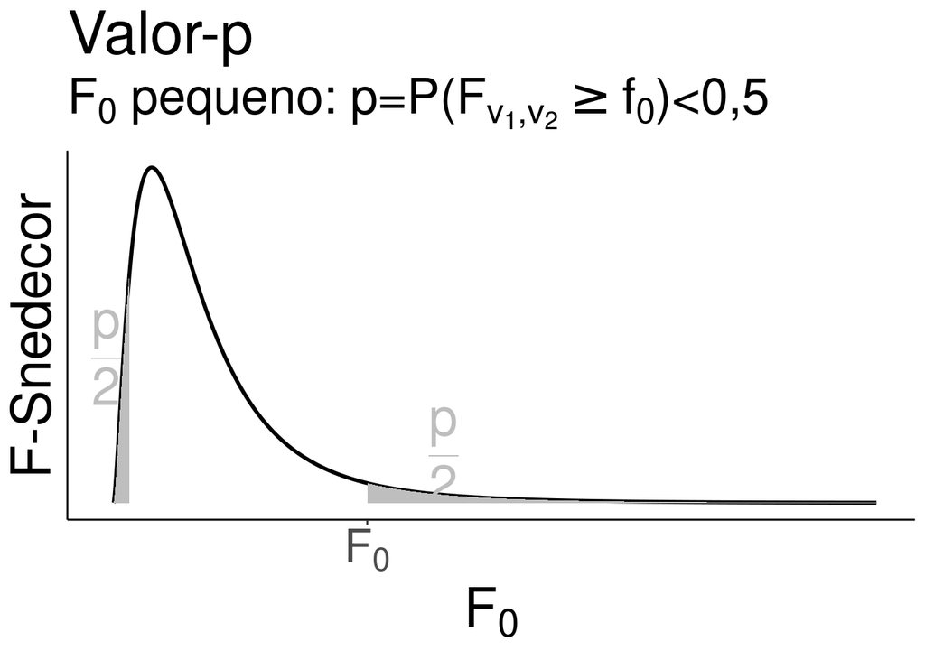

```r
ggsave("../figures/test-variance-valor-p-1.png")
ggsave("../figures/test-variance-valor-p-1.pdf")
ggplot(dados)+
  geom_line(aes(x = z, y = f), color = "black", size = 1) +
  labs(x = TeX("$F_0$"), y = "F-Snedecor",
       title = "Valor-p",
       subtitle = TeX("$F_0$ pequeno: $p=P(F_{v_1, v_2} \\geq f_0) < 0,5$")) +
  scale_x_continuous(breaks = c(upper),
                     labels = c(TeX("$F_0$"))) +
  scale_y_continuous(breaks = NULL) +
  geom_ribbon(data = dplyr::filter(dados, z > upper),
              aes(x = z, y = f, ymin = 0, ymax = f),
              fill = "gray") +
  geom_ribbon(data = dplyr::filter(dados, z < lower),
              aes(x = z, y = f, ymin = 0, ymax = f),
              fill = "gray") +
  theme_classic() +
  theme(axis.title = element_text(size = 30),
        axis.text = element_text(size = 25),
        title = element_text(size = 27)) +
  annotate("text", x = -0.1, y = 0.30, label = "frac(p,2)", parse = T,
           color = "gray", size = 10) +
  annotate("text", x = upper + 1, y = 0.10, label = "frac(p,2)", parse = T,
           color = "gray", size = 10)
```

```r
ggsave("../figures/test-variance-valor-p-2.png")
ggsave("../figures/test-variance-valor-p-2.pdf")
```

Below we implement the size of sample given the power of test. I have not found in `MATLAB` and in the `R`. In this approach, we assume $n=n_1=n_2$.

```r
samp_size_var_test <- function(sigma1, sigma2, alpha = 0.05, power = 0.95){
  aux <- function(k){
    k %>%
      map_dbl(~ (1  -
                   pf(qf(1 - alpha / 2, df1 = .x, df2 = .x) * sigma2^2 / sigma1^2, df1 = .x, df2 = .x) +
                   pf(qf(alpha / 2, df1 = .x, df2 = .x) * sigma2^2 / sigma1^2, df1 = .x, df2 = .x) -
                   power)^2)
  }

  (nlminb(1, aux, lower = 1e-8, upper = Inf)$par + 1) %>% ceiling()
}

samp_size_var_test(sigma1 = 15, sigma2 = 25, alpha = 0.05, power = 0.99)
```

```
[1] 73
```

## unilateral test on variance ($H_1$ upper).

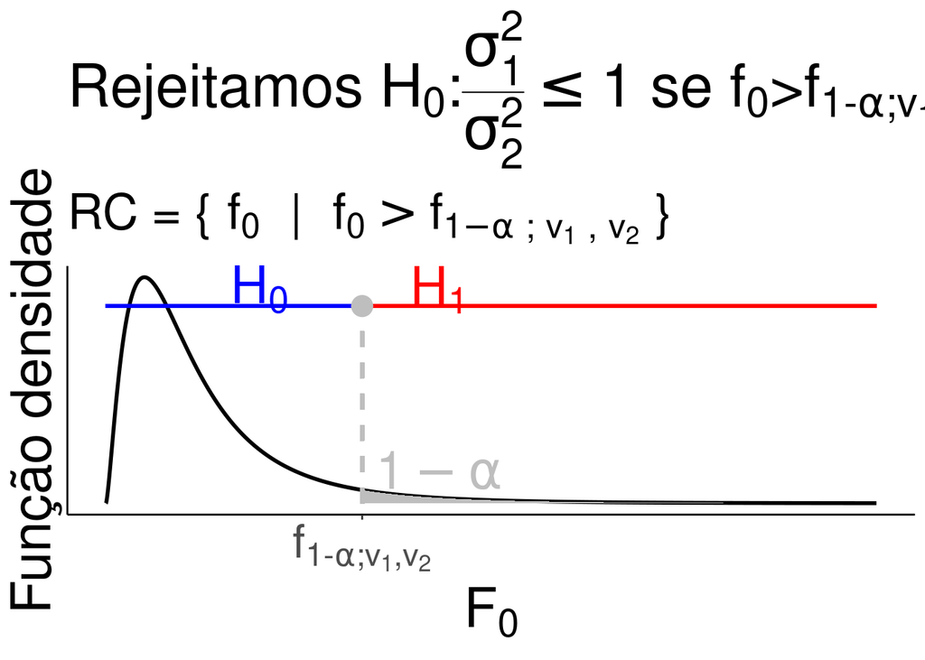

```r
v1 <- 5
v2 <- 10
xmax <- 10
z <- seq(from = 0, to= xmax, by = 0.001)
f <- df(z, df1 = v1, df2 = v2)
dados <- tibble(z=z, f=f)
a <- 0.05
upper <- qf(1 - a, df1 = v1, df2 = v2)


ggplot(dados)+
  geom_line(aes(x = z, y = f), color = "black", size = 1) +
  labs(x = TeX("$F_0$"), y = "Função densidade",
       title = TeX("Rejeitamos $H_0: \\frac{\\sigma_1^2}{\\sigma_2^2} \\leq 1$ se $f_0 > f_{1-\\alpha;v_1, v_2}$"),
       subtitle = bquote("RC = {" ~ f[0] ~ " | " ~ f[0] > f[1-alpha~';'~v[1]~','~v[2]]~"}")) +
  scale_x_continuous(breaks = c(upper),
                     labels = c(TeX("$f_{1-\\alpha;v_1, v_2}$"))) +
  scale_y_continuous(breaks = NULL) +
  geom_ribbon(data = dplyr::filter(dados, z > upper),
              aes(x = z, y = f, ymin = 0, ymax = f),
              fill = "gray")+
  theme_classic() +
  theme(axis.title = element_text(size = 30),
        axis.text = element_text(size = 25),
        title = element_text(size = 27)) +
  geom_segment(x = upper, xend = xmax, y = 0.6, yend =0.6, size = 1, color = "red") +
  geom_segment(x = 0, xend = upper, y = 0.6, yend =0.6, size = 1, color = "blue") +
  geom_segment(x = upper, xend = upper, y = 0, yend = 0.6,
               linetype = "dashed", color = "gray", size = 1) +
  geom_point(data = tibble(x = c(upper), y = c(0.6)),
             aes(x = x, y = y), size = 5,color  = "gray") +
  annotate("text", x = 2, y = 0.65, label = "H[0]",
           size = 10, color = "blue", parse = T) +
  annotate("text", x = upper + 1, y = 0.65, label = "H[1]",
           size = 10, color = "red", parse = T) +
  annotate("text", x = upper + 1, y = 0.10, label = "1-alpha", parse = T,
           color = "gray", size = 10)
```

```r
ggsave("../figures/test-variance-unilateral-h1-upper.png")
ggsave("../figures/test-variance-unilateral-h1-upper.pdf")
```

In this point, we compute the sample size for altertive hipothesis $H_1: \frac{\sigma_1^2}{\sigma_2^2} > 1$.

```r
samp_size_var_test <- function(sigma1, sigma2, alpha = 0.05, power = 0.95){
  aux <- function(k){
    k %>%
      map_dbl(~ (1  -
                   pf(qf(1 - alpha, df1 = .x, df2 = .x) * sigma2^2 / sigma1^2, df1 = .x, df2 = .x) -
                   power)^2)
  }

  (nlminb(1, aux, lower = 1e-8, upper = Inf)$par + 1) %>% ceiling()
}

samp_size_var_test(sigma1 = 10, sigma2 = 5, alpha = 0.05, power = 0.95)
```

```
[1] 25
```

## unilateral test on variance ($H_1$ lower).

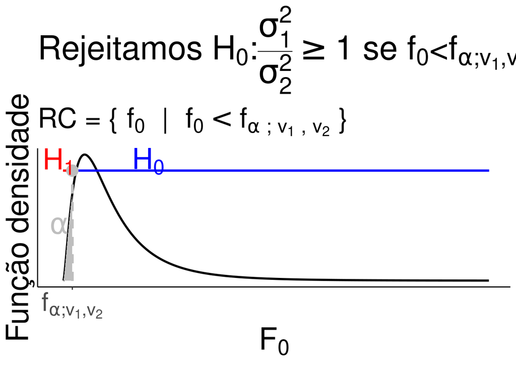

```r
v1 <- 5
v2 <- 10
xmax <- 10
z <- seq(from = 0, to= xmax, by = 0.001)
f <- df(z, df1 = v1, df2 = v2)
dados <- tibble(z=z, f=f)
a <- 0.05
lower <- qf(a, df1 = v1, df2 = v2)



ggplot(dados)+
  geom_line(aes(x = z, y = f), color = "black", size = 1) +
  labs(x = TeX("$F_0$"), y = "Função densidade",
       title = TeX("Rejeitamos $H_0: \\frac{\\sigma_1^2}{\\sigma_2^2} \\geq 1$ se $f_0 < f_{\\alpha;v_1, v_2}$"),
       subtitle = bquote("RC = {" ~ f[0] ~ " | " ~ f[0] < f[alpha~';'~v[1]~','~v[2]]~"}")) +
  scale_x_continuous(breaks = c(lower),
                     labels = c(TeX("$f_{\\alpha;v_1, v_2}$"))) +
  scale_y_continuous(breaks = NULL) +
  geom_ribbon(data = dplyr::filter(dados, z < lower),
              aes(x = z, y = f, ymin = 0, ymax = f),
              fill = "gray")+
  theme_classic() +
  theme(axis.title = element_text(size = 30),
        axis.text = element_text(size = 25),
        title = element_text(size = 27)) +
  geom_segment(x = 0, xend = lower, y = 0.6, yend =0.6, size = 1, color = "red") +
  geom_segment(x = lower, xend = xmax, y = 0.6, yend =0.6, size = 1, color = "blue") +
  geom_segment(x = lower, xend = lower, y = 0, yend = 0.6,
               linetype = "dashed", color = "gray", size = 1) +
  geom_point(data = tibble(x = c(lower), y = c(0.6)),
             aes(x = x, y = y), size = 5,color  = "gray") +
  annotate("text", x = -0.1, y = 0.65, label = "H[1]",
           size = 10, color = "red", parse = T) +
  annotate("text", x = 2, y = 0.65, label = "H[0]",
           size = 10, color = "blue", parse = T) +
  annotate("text", x = -0.1, y = 0.30, label = "alpha", parse = T,
           color = "gray", size = 10)
```

```r
ggsave("../figures/test-variance-unilateral-h1-lower.png")
ggsave("../figures/test-variance-unilateral-h1-lower.pdf")
```

Below we simulate an example.

```r
set.seed(1235813)
n1 <- 26
n2 <- 21
s1 <- 5
s2 <- 10

amostra1 <- rnorm(n1, sd = 5)
amostra2 <- rnorm(n2, sd = 10)

sd(amostra1) %>% round(2)
```

```
[1] 5.21
```

```r
sd(amostra2) %>% round(2)
```

```
[1] 13.38
```

In this point, we estimate the sample size using the folling equation:

```r
samp_size_var_test <- function(sigma1, sigma2, alpha = 0.05, power = 0.95){
  aux <- function(k){
    k %>%
      map_dbl(~ ( pf(qf(alpha, df1 = .x, df2 = .x) * sigma2^2 / sigma1^2, df1 = .x, df2 = .x) -
                    power)^2)
  }

  (nlminb(1, aux, lower = 1e-8, upper = Inf)$par + 1) %>% ceiling()
}

samp_size_var_test(sigma1 = 5, sigma2 = 10, alpha = 0.05, power = 0.99)
```

```
[1] 36
```

## Normal distribution with normal distribution and unknown variances

We want to compare the means of two normal populations $N(\mu_1, \sigma_1^2)$ e $N(\mu_2, \sigma_2^2)$, where $\sigma_1^2$ and $\sigma_2^2$ are equal and unknown. Here, we illustrate the ideas of decision, the critical regions and the critical values.

### Bilateral

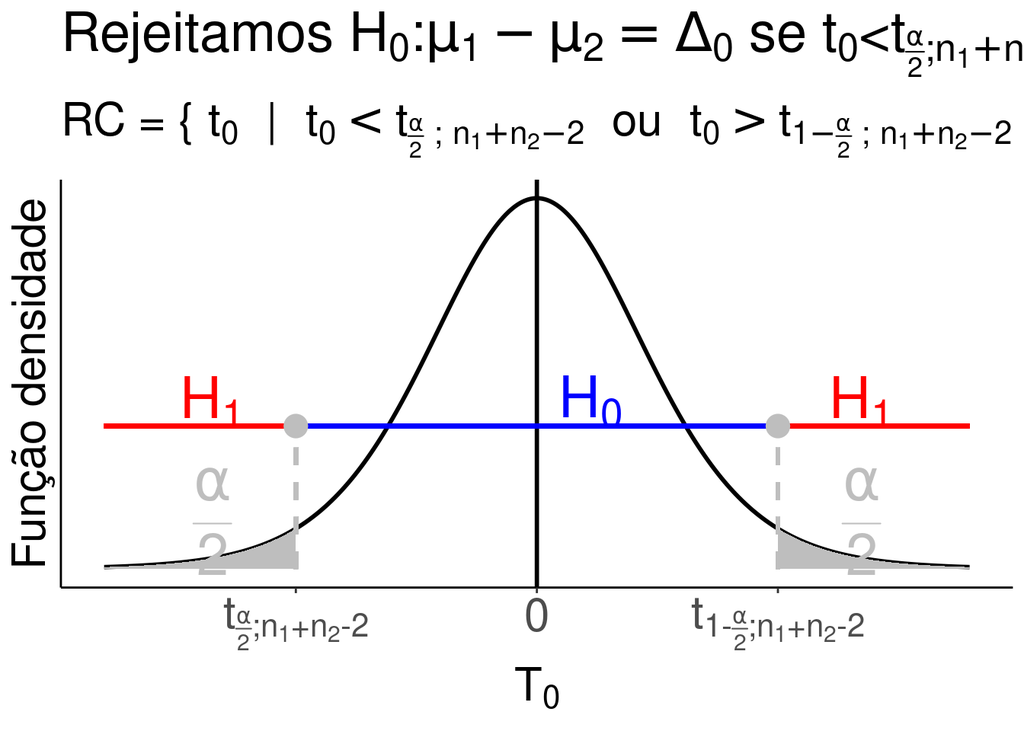

```r
gl <- 10
xmin <- -4
xmax <- 4
z <- seq(from = xmin, to= xmax, by = 0.001)
f <- dt(z, df = gl)
dados <- tibble(z=z, f=f)
a <- 0.05
lower <- qt(a / 2, df = gl)
upper <- qt(1 - a / 2, df = gl)

ggplot(dados)+
  geom_line(aes(x = z, y = f), color = "black", size = 1) +
  labs(x = TeX("$T_0$"), y = "Função densidade",
       title = TeX("Rejeitamos $H_0: \\mu_{1} - \\mu_{2} = \\Delta_{0}$ se $t_0 < t_{\\frac{\\alpha}{2};n_1 + n_2 -2}$ ou $t_0 > t_{1-\\frac{\\alpha}{2};n_1 + n_2 -2}$"),
       subtitle = bquote("RC = {" ~ t[0] ~ " | " ~ t[0] < t[frac(alpha, 2)~';'~n[1]+n[2]-2] ~ " ou " ~ t[0] > t[1-frac(alpha, 2)~';'~n[1]+n[2]-2] ~ "}")) +
  scale_x_continuous(breaks = c(lower, 0, upper),
                     labels = c(TeX("$t_{\\frac{\\alpha}{2};n_1+n_2-2}$"), "0",
                                TeX("$t_{1- \\frac{\\alpha}{2}; n_1+n_2-2}$"))) +
  scale_y_continuous(breaks = NULL) +
  geom_ribbon(data = dplyr::filter(dados, z < lower),
              aes(x = z, y = f, ymin = 0, ymax = f),
              fill = "gray") +
  geom_ribbon(data = dplyr::filter(dados, z > upper),
              aes(x = z, y = f, ymin = 0, ymax = f),
              fill = "gray") +
  theme_classic() +
  theme(axis.title = element_text(size = 22.5),
        axis.text = element_text(size = 22.5),
        title = element_text(size = 22.5)) +
  geom_vline(xintercept = 0, color = "black", size = 1) +
  geom_segment(x = xmin, xend = lower, y = 0.15, yend =0.15, size = 1, color = "red") +
  geom_segment(x = upper, xend = xmax, y = 0.15, yend =0.15, size = 1, color = "red") +
  geom_segment(x = lower, xend = upper, y = 0.15, yend =0.15, size = 1, color = "blue") +
  geom_segment(x = lower, xend = lower, y = 0, yend = 0.15,
               linetype = "dashed", color = "gray", size = 1) +
  geom_segment(x = upper, xend = upper, y = 0, yend = 0.15,
               linetype = "dashed", color = "gray", size = 1) +
  geom_point(data = tibble(x = c(lower, upper), y = c(0.15, 0.15)),
             aes(x = x, y = y), size = 5,color  = "gray") +
  annotate("text", x = -3, y = 0.175, label = "H[1]",
           size = 10, color = "red", parse = T) +
  annotate("text", x = 3, y = 0.175, label = "H[1]",
           size = 10, color = "red", parse = T) +
  annotate("text", x = 0.5, y = 0.175, label = "H[0]",
           size = 10, color = "blue", parse = T) +
  annotate("text", x = -3, y = 0.05, label = "frac(alpha, 2)", parse = T,
           color = "gray", size = 10) +
  annotate("text", x = 3, y = 0.05, label = "frac(alpha, 2)", parse = T,
           color = "gray", size = 10)
```

```r
ggsave("../figures/2-pop-normal-s2-unknown-equal-bilateral.png")
ggsave("../figures/2-pop-normal-s2-unknown-equal-bilateral.pdf")
```

Bilateral example from montgomery book for engineers.

```r
x <- c(
  91.50,
  94.18,
  92.18,
  95.39,
  91.79,
  89.07,
  94.72,
  89.21
)
y <- c(
  89.19,
  90.95,
  90.46,
  93.21,
  97.19,
  97.04,
  91.07,
  92.75
)

dados <- tibble(`Número de observações` = seq_along(x),
                `Catalisador 1` = x, `Catalisador 2` = y)

dados %>%
  xtable(caption = "Rendimento para os catalisadores 1 e 2.",
         label = "tab:catalisadores",
         digits = 1, align = rep("c", ncol(dados) + 1)) %>%
  print.xtable(booktabs = T,
               include.rownames = F,
               format.args = list(decimal.mark = ","))
```

```
% latex table generated in R 4.1.0 by xtable 1.8-4 package
% Sun May 30 15:08:29 2021
\begin{table}[ht]
\centering
\begin{tabular}{ccc}
  \toprule
Número de observações & Catalisador 1 & Catalisador 2 \\
  \midrule
 1 & 91,5 & 89,2 \\
   2 & 94,2 & 91,0 \\
   3 & 92,2 & 90,5 \\
   4 & 95,4 & 93,2 \\
   5 & 91,8 & 97,2 \\
   6 & 89,1 & 97,0 \\
   7 & 94,7 & 91,1 \\
   8 & 89,2 & 92,8 \\
   \bottomrule
\end{tabular}
\caption{Rendimento para os catalisadores 1 e 2.}
\label{tab:catalisadores}
\end{table}
```

```r
tab <- dados %>%
  summarise(n = n(),
            delta0 = 0,
            media1 = mean(`Catalisador 1`) %>% round(2),
            media2 = mean(`Catalisador 2`) %>% round(2),
            sd1 = sd(`Catalisador 1`) %>% round(2),
            sd2 = sd(`Catalisador 2`) %>% round(2),
            sd_d = (((n - 1) * var(`Catalisador 1`) + (n - 1) * var(`Catalisador 2`)) /
              (2 * n - 2)) %>% sqrt() %>% round(2),
            t0 = ((media1 - media2 - delta0) / (sd_d * sqrt(2 / n))) %>%  round(2))
```

Below we compute the power.

```r
m1  <-  92
m2 <- 93
s <- 3
n1 <- n2 <- 8
gl <- n1 + n2 - 2
d <- (m1 - m2) / s

pwr::pwr.t2n.test(n1 = n1, n2 = n2, d = d, sig.level = 0.05,
                  power = NULL, alternative = 'two.sided')
```

[output not shown]

Below we compute the sample size

```r
samp_size_t2_equal_var <- function(m1, m2, s, delta0 = 0, alpha = 0.05, power = 0.95){
  aux <- function(k){
    k %>%
      map_dbl(~ (1 -
                   pt(pt(1 - alpha / 2, df = 2 * .x - 2), df = 2 * .x - 2,
                      ncp = (m1 - m2 - delta0) / (s * sqrt(2 / .x))) +
                   pt(pt(alpha / 2, df = 2 * .x - 2), df = 2 * .x - 2,
                      ncp = (m1 - m2 - delta0) / (s * sqrt(2 / .x)))-
                   power)^2)
  }

  nlminb(4, aux, lower = 3, upper = Inf)$par %>% ceiling()
}

samp_size_t2_equal_var(92, 93, 3, delta0 = 0, alpha = 0.05, power = 0.99)
```

```
[1] 46
```

### unilateral ($H_1$ lower)

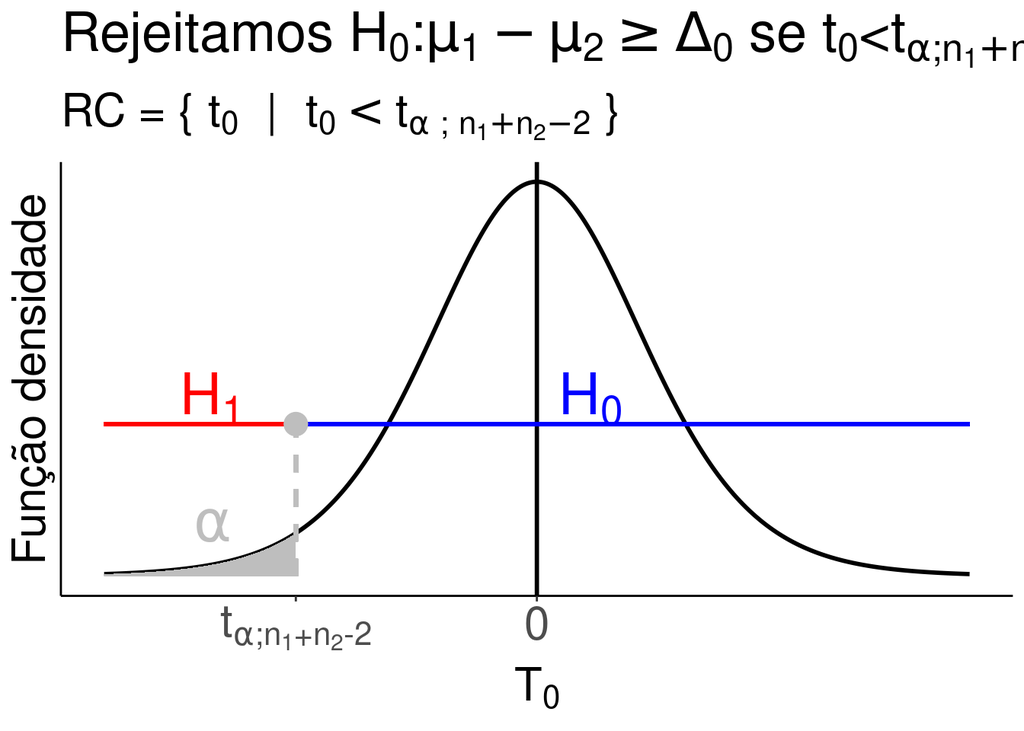

```r
gl <- 10
xmin <- -4
xmax <- 4
z <- seq(from = xmin, to= xmax, by = 0.001)
f <- dt(z, df = gl)
dados <- tibble(z=z, f=f)
a <- 0.05
lower <- qt(a / 2, df = gl)
upper <- qt(1 - a / 2, df = gl)

ggplot(dados)+
  geom_line(aes(x = z, y = f), color = "black", size = 1) +
  labs(x = TeX("$T_0$"), y = "Função densidade",
       title = TeX("Rejeitamos $H_0: \\mu_{1} - \\mu_{2} \\geq \\Delta_{0}$ se $t_0 < t_{\\alpha;n_1 + n_2 -2}$"),
       subtitle = bquote("RC = {" ~ t[0] ~ " | " ~ t[0] < t[alpha~';'~n[1]+n[2]-2] ~ "}")) +
  scale_x_continuous(breaks = c(lower, 0),
                     labels = c(TeX("$t_{\\alpha;n_1+n_2-2}$"), "0")) +
  scale_y_continuous(breaks = NULL) +
  geom_ribbon(data = dplyr::filter(dados, z < lower),
              aes(x = z, y = f, ymin = 0, ymax = f),
              fill = "gray") +
  theme_classic() +
  theme(axis.title = element_text(size = 22.5),
        axis.text = element_text(size = 22.5),
        title = element_text(size = 22.5)) +
  geom_vline(xintercept = 0, color = "black", size = 1) +
  geom_segment(x = xmin, xend = lower, y = 0.15, yend =0.15, size = 1, color = "red") +
  geom_segment(x = lower, xend = xmax, y = 0.15, yend =0.15, size = 1, color = "blue") +
  geom_segment(x = lower, xend = lower, y = 0, yend = 0.15,
               linetype = "dashed", color = "gray", size = 1) +
  geom_point(data = tibble(x = c(lower), y = c(0.15)),
             aes(x = x, y = y), size = 5,color  = "gray") +
  annotate("text", x = -3, y = 0.175, label = "H[1]",
           size = 10, color = "red", parse = T) +
  annotate("text", x = 0.5, y = 0.175, label = "H[0]",
           size = 10, color = "blue", parse = T) +
  annotate("text", x = -3, y = 0.05, label = "alpha", parse = T,
           color = "gray", size = 10)
```

```r
ggsave("../figures/2-pop-normal-s2-unknown-equal-h1-lower.png")
ggsave("../figures/2-pop-normal-s2-unknown-equal-h1-lower.pdf")
```

```r
set.seed(1234)
n <- 12
low <- rnorm(n, mean = 260, sd = 30) %>% round(0)
high <- rnorm(n, mean = 350, sd = 30) %>% round(0)
dados <- tibble(`Vibração baixa` = low,
                `Vibração alta` = high)

dados %>%
  xtable(caption = "Força de moagem para níveis baixos e altos de vibração",
         label = "tab:moagem",
         align = rep("c", ncol(dados) + 1),
         digits = 0) %>%
  print.xtable(booktabs = T,
               format.args = list(decimal.mark = ","),
               include.rownames = F)
```

```
% latex table generated in R 4.1.0 by xtable 1.8-4 package
% Sun May 30 15:08:30 2021
\begin{table}[ht]
\centering
\begin{tabular}{cc}
  \toprule
Vibração baixa & Vibração alta \\
  \midrule
224 & 327 \\
  268 & 352 \\
  293 & 379 \\
  190 & 347 \\
  273 & 335 \\
  275 & 323 \\
  243 & 325 \\
  244 & 422 \\
  243 & 354 \\
  233 & 335 \\
  246 & 337 \\
  230 & 364 \\
   \bottomrule
\end{tabular}
\caption{Força de moagem para níveis baixos e altos de vibração}
\label{tab:moagem}
\end{table}
```

```r
tab <- dados %>%
  summarise(n = n(),
            delta0 = 0,
            mediaBaixa = mean(`Vibração baixa`) %>% round(2),
            mediaAlta = mean(`Vibração alta`) %>% round(2),
            sdBaixa = sd(`Vibração baixa`) %>% round(2),
            sdAlta = sd(`Vibração alta`) %>% round(2),
            sd_d = (((n-1) * var(`Vibração baixa`) + (n-1) * var(`Vibração alta`)) / (2 * n - 2)) %>% sqrt() %>% round(2),
            t0 = ((mediaBaixa - mediaAlta - delta0) / (sd_d * sqrt(2 / n))) %>% round(2))
```

### unilateral ($H_1$ upper)

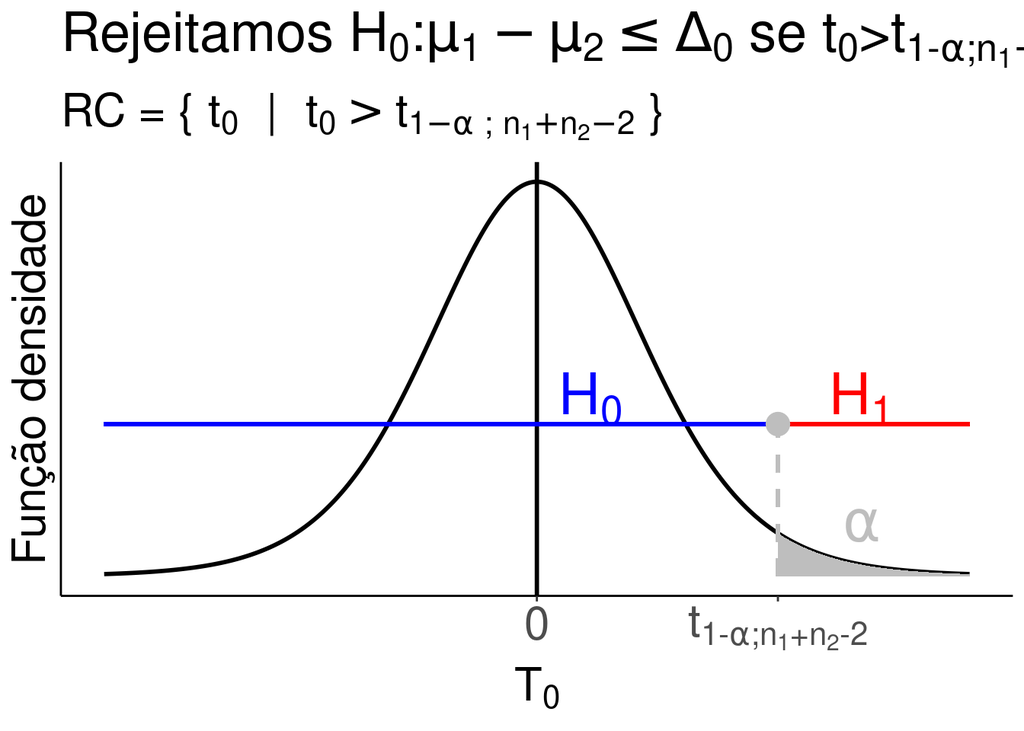

```r
gl <- 10
xmin <- -4
xmax <- 4
z <- seq(from = xmin, to= xmax, by = 0.001)
f <- dt(z, df = gl)
dados <- tibble(z=z, f=f)
a <- 0.05
lower <- qt(a / 2, df = gl)
upper <- qt(1 - a / 2, df = gl)

ggplot(dados)+
  geom_line(aes(x = z, y = f), color = "black", size = 1) +
  labs(x = TeX("$T_0$"), y = "Função densidade",
       title = TeX("Rejeitamos $H_0: \\mu_{1} - \\mu_{2} \\leq \\Delta_{0}$ se $t_0 > t_{1-\\alpha;n_1 + n_2 -2}$"),
       subtitle = bquote("RC = {" ~ t[0] ~ " | " ~ t[0] > t[1-alpha~';'~n[1]+n[2]-2] ~ "}")) +
  scale_x_continuous(breaks = c(0, upper),
                     labels = c(0, TeX("$t_{1-\\alpha;n_1+n_2-2}$"))) +
  scale_y_continuous(breaks = NULL) +
  geom_ribbon(data = dplyr::filter(dados, z > upper),
              aes(x = z, y = f, ymin = 0, ymax = f),
              fill = "gray") +
  theme_classic() +
  theme(axis.title = element_text(size = 22.5),
        axis.text = element_text(size = 22.5),
        title = element_text(size = 22.5)) +
  geom_vline(xintercept = 0, color = "black", size = 1) +
  geom_segment(x = xmin, xend = upper, y = 0.15, yend =0.15, size = 1, color = "blue") +
  geom_segment(x = upper, xend = xmax, y = 0.15, yend =0.15, size = 1, color = "red") +
  geom_segment(x = upper, xend = upper, y = 0, yend = 0.15,
               linetype = "dashed", color = "gray", size = 1) +
  geom_point(data = tibble(x = c(upper), y = c(0.15)),
             aes(x = x, y = y), size = 5,color  = "gray") +
  annotate("text", x = 3, y = 0.175, label = "H[1]",
           size = 10, color = "red", parse = T) +
  annotate("text", x = 0.5, y = 0.175, label = "H[0]",
           size = 10, color = "blue", parse = T) +
  annotate("text", x = 3, y = 0.05, label = "alpha", parse = T,
           color = "gray", size = 10)
```

```r
ggsave("../figures/2-pop-normal-s2-unknown-equal-h1-upper.png")
ggsave("../figures/2-pop-normal-s2-unknown-equal-h1-upper.pdf")
```

```r
set.seed(1235813)
n1 <- 15
n2 <- 25
s1 <- 3
s2 <- 10
m1 <- 30
m2 <- 50
x1 <- rnorm(n1, mean = m1, sd = s1)
x2 <- rnorm(n2, mean = m2, sd = s2)

tibble(x1) %>% summarise(n1 = n(), media1 = mean(x1), dp1 = sd(x1))
```

| n1 | media1 | dp1 |
| --- | --- | --- |
| 15 | 30.48038 | 2.514449 |

```r
tibble(x2) %>% summarise(n1 = n(), media1 = mean(x2), dp1 = sd(x2))
```

| n1 | media1 | dp1 |
| --- | --- | --- |
| 25 | 52.63254 | 13.31611 |

## Normal distribution with normal distribution and unknown variances

We want to compare the means of two normal populations $N(\mu_1, \sigma_1^2)$ e $N(\mu_2, \sigma_2^2)$, where $\sigma_1^2$ and $\sigma_2^2$ are unknown and $\sigma_1^2 \neq \sigma_2^2$. Here, we illustrate the ideas of decision, the critical regions and the critical values.

### Bilateral

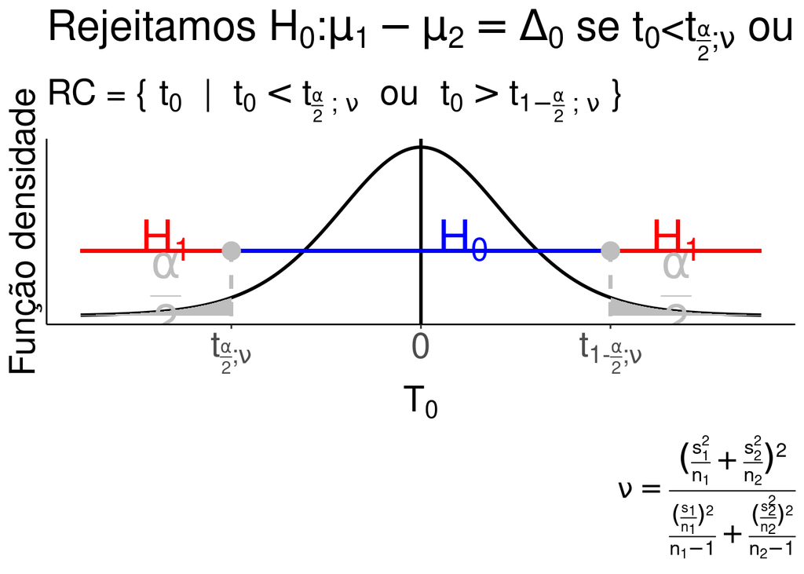

```r
gl <- 10
xmin <- -4
xmax <- 4
z <- seq(from = xmin, to= xmax, by = 0.001)
f <- dt(z, df = gl)
dados <- tibble(z=z, f=f)
a <- 0.05
lower <- qt(a / 2, df = gl)
upper <- qt(1 - a / 2, df = gl)

ggplot(dados)+
  geom_line(aes(x = z, y = f), color = "black", size = 1) +
  labs(x = TeX("$T_0$"), y = "Função densidade",
       title = TeX("Rejeitamos $H_0: \\mu_{1} - \\mu_{2} = \\Delta_{0}$ se $t_0 < t_{\\frac{\\alpha}{2};\\nu}$ ou $t_0 > t_{1-\\frac{\\alpha}{2};\\nu}$"),
       subtitle = bquote("RC = {" ~ t[0] ~ " | " ~ t[0] < t[frac(alpha, 2)~';'~nu] ~ " ou " ~ t[0] > t[1-frac(alpha, 2)~';'~nu] ~ "}"),
       caption = bquote(nu == frac((frac(s[1]^2, n[1]) + frac(s[2]^2, n[2]))^2,
                                    frac((frac(s[1], n[1]))^2, n[1]-1) + frac((frac(s[2]^2, n[2]))^2, n[2]-1) ))) +
  scale_x_continuous(breaks = c(lower, 0, upper),
                     labels = c(TeX("$t_{\\frac{\\alpha}{2};\\nu}$"), "0",
                                TeX("$t_{1- \\frac{\\alpha}{2}; \\nu}$"))) +
  scale_y_continuous(breaks = NULL) +
  geom_ribbon(data = dplyr::filter(dados, z < lower),
              aes(x = z, y = f, ymin = 0, ymax = f),
              fill = "gray") +
  geom_ribbon(data = dplyr::filter(dados, z > upper),
              aes(x = z, y = f, ymin = 0, ymax = f),
              fill = "gray") +
  theme_classic() +
  theme(axis.title = element_text(size = 22),
        axis.text = element_text(size = 22),
        title = element_text(size = 22)) +
  geom_vline(xintercept = 0, color = "black", size = 1) +
  geom_segment(x = xmin, xend = lower, y = 0.15, yend =0.15, size = 1, color = "red") +
  geom_segment(x = upper, xend = xmax, y = 0.15, yend =0.15, size = 1, color = "red") +
  geom_segment(x = lower, xend = upper, y = 0.15, yend =0.15, size = 1, color = "blue") +
  geom_segment(x = lower, xend = lower, y = 0, yend = 0.15,
               linetype = "dashed", color = "gray", size = 1) +
  geom_segment(x = upper, xend = upper, y = 0, yend = 0.15,
               linetype = "dashed", color = "gray", size = 1) +
  geom_point(data = tibble(x = c(lower, upper), y = c(0.15, 0.15)),
             aes(x = x, y = y), size = 5,color  = "gray") +
  annotate("text", x = -3, y = 0.175, label = "H[1]",
           size = 10, color = "red", parse = T) +
  annotate("text", x = 3, y = 0.175, label = "H[1]",
           size = 10, color = "red", parse = T) +
  annotate("text", x = 0.5, y = 0.175, label = "H[0]",
           size = 10, color = "blue", parse = T) +
  annotate("text", x = -3, y = 0.05, label = "frac(alpha, 2)", parse = T,
           color = "gray", size = 10) +
  annotate("text", x = 3, y = 0.05, label = "frac(alpha, 2)", parse = T,
           color = "gray", size = 10)
```

```r
ggsave("../figures/2-pop-normal-s2-unknown-different-bilateral.png")
ggsave("../figures/2-pop-normal-s2-unknown-different-bilateral.pdf")
```

Below we have a example from Montgomery.

```r
x <- c("Phoenix, 3",
       "Chandler, 7",
       "Gilbert, 25",
       "Glendale, 10",
       "Mesa, 15",
       "Paradise Valley, 6",
       "Peoria, 12",
       "Scottsdale, 25",
       "Tempe, 15",
       "Sun City, 7"
)

y <- c( "Rimrock, 48",
        "Goodyear, 44",
        "New River, 40",
        "Apache Junction, 38",
        "Buckeye, 33",
        "Nogales, 21",
        "Black Canyon City, 20",
        "Sedona, 12",
        "Payson, 1",
        "Casa Grande, 18"
)

cbind(x, y) %>%
  xtable(align = rep("c", 3)) %>%
  print.xtable(include.rownames = F)
```

```
% latex table generated in R 4.1.0 by xtable 1.8-4 package
% Sun May 30 15:08:33 2021
\begin{table}[ht]
\centering
\begin{tabular}{cc}
  \hline
x & y \\
  \hline
Phoenix, 3 & Rimrock, 48 \\
  Chandler, 7 & Goodyear, 44 \\
  Gilbert, 25 & New River, 40 \\
  Glendale, 10 & Apache Junction, 38 \\
  Mesa, 15 & Buckeye, 33 \\
  Paradise Valley, 6 & Nogales, 21 \\
  Peoria, 12 & Black Canyon City, 20 \\
  Scottsdale, 25 & Sedona, 12 \\
  Tempe, 15 & Payson, 1 \\
  Sun City, 7 & Casa Grande, 18 \\
   \hline
\end{tabular}
\end{table}
```

### Unilateral ($H_1$ lower)

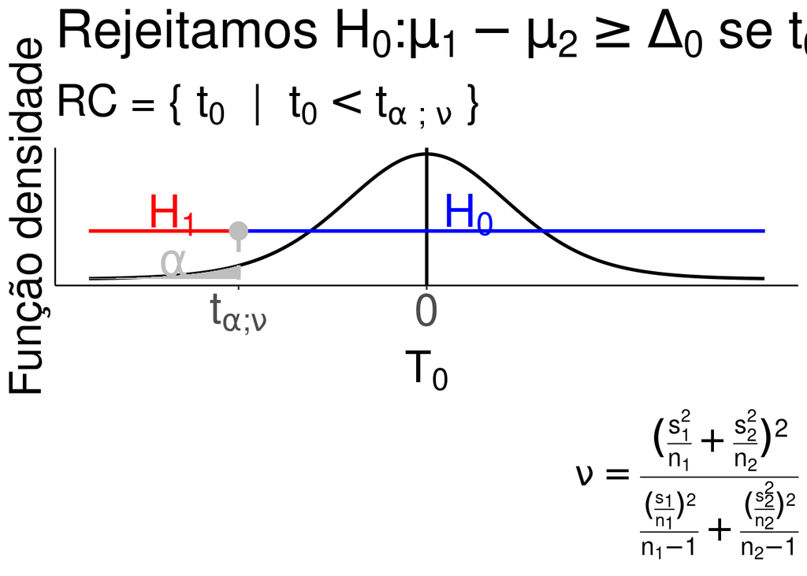

```r
gl <- 10
xmin <- -4
xmax <- 4
z <- seq(from = xmin, to= xmax, by = 0.001)
f <- dt(z, df = gl)
dados <- tibble(z=z, f=f)
a <- 0.05
lower <- qt(a / 2, df = gl)
upper <- qt(1 - a / 2, df = gl)

ggplot(dados)+
  geom_line(aes(x = z, y = f), color = "black", size = 1) +
  labs(x = TeX("$T_0$"), y = "Função densidade",
       title = TeX("Rejeitamos $H_0: \\mu_{1} - \\mu_{2} \\geq \\Delta_{0}$ se $t_0 < t_{\\alpha;\\nu}$"),
       subtitle = bquote("RC = {" ~ t[0] ~ " | " ~ t[0] < t[alpha~';'~nu] ~ "}"),
       caption = bquote(nu == frac((frac(s[1]^2, n[1]) + frac(s[2]^2, n[2]))^2,
                                    frac((frac(s[1], n[1]))^2, n[1]-1) + frac((frac(s[2]^2, n[2]))^2, n[2]-1) ))) +
  scale_x_continuous(breaks = c(lower, 0),
                     labels = c(TeX("$t_{\\alpha;\\nu}$"), "0")) +
  scale_y_continuous(breaks = NULL) +
  geom_ribbon(data = dplyr::filter(dados, z < lower),
              aes(x = z, y = f, ymin = 0, ymax = f),
              fill = "gray") +
  theme_classic() +
  theme(axis.title = element_text(size = 27.5),
        axis.text = element_text(size = 27.5),
        title = element_text(size = 27.5)) +
  geom_vline(xintercept = 0, color = "black", size = 1) +
  geom_segment(x = xmin, xend = lower, y = 0.15, yend =0.15, size = 1, color = "red") +
  geom_segment(x = lower, xend = xmax, y = 0.15, yend =0.15, size = 1, color = "blue") +
  geom_segment(x = lower, xend = lower, y = 0, yend = 0.15,
               linetype = "dashed", color = "gray", size = 1) +
  geom_point(data = tibble(x = c(lower), y = c(0.15)),
             aes(x = x, y = y), size = 5,color  = "gray") +
  annotate("text", x = -3, y = 0.2, label = "H[1]",
           size = 10, color = "red", parse = T) +
  annotate("text", x = 0.5, y = 0.2, label = "H[0]",
           size = 10, color = "blue", parse = T) +
  annotate("text", x = -3, y = 0.05, label = "alpha", parse = T,
           color = "gray", size = 10) #+
```

```r
ggsave("../figures/2-pop-normal-s2-unknown-different-h1-lower.png")
ggsave("../figures/2-pop-normal-s2-unknown-different-h1-lower.pdf")
```

### Unilateral ($H_1$ upper)

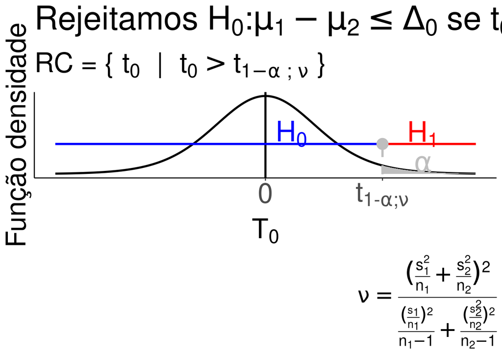

```r
gl <- 10
xmin <- -4
xmax <- 4
z <- seq(from = xmin, to= xmax, by = 0.001)
f <- dt(z, df = gl)
dados <- tibble(z=z, f=f)
a <- 0.05
lower <- qt(a / 2, df = gl)
upper <- qt(1 - a / 2, df = gl)

ggplot(dados)+
  geom_line(aes(x = z, y = f), color = "black", size = 1) +
  labs(x = TeX("$T_0$"), y = "Função densidade",
       title = TeX("Rejeitamos $H_0: \\mu_{1} - \\mu_{2} \\leq \\Delta_{0}$ se $t_0 > t_{1-\\alpha;\\nu}$"),
       subtitle = bquote("RC = {" ~ t[0] ~ " | " ~ t[0] > t[1-alpha~';'~nu] ~ "}"),
       caption = bquote(nu == frac((frac(s[1]^2, n[1]) + frac(s[2]^2, n[2]))^2,
                                    frac((frac(s[1], n[1]))^2, n[1]-1) + frac((frac(s[2]^2, n[2]))^2, n[2]-1) ))) +
  scale_x_continuous(breaks = c(0, upper),
                     labels = c("0", TeX("$t_{1-\\alpha;\\nu}$"))) +
  scale_y_continuous(breaks = NULL) +
  geom_ribbon(data = dplyr::filter(dados, z > upper),
              aes(x = z, y = f, ymin = 0, ymax = f),
              fill = "gray") +
  theme_classic() +
  theme(axis.title = element_text(size = 27.5),
        axis.text = element_text(size = 27.5),
        title = element_text(size = 27.5)) +
  geom_vline(xintercept = 0, color = "black", size = 1) +
  geom_segment(x = xmin, xend = upper, y = 0.15, yend =0.15, size = 1, color = "blue") +
  geom_segment(x = upper, xend = xmax, y = 0.15, yend =0.15, size = 1, color = "red") +
  geom_segment(x = upper, xend = upper, y = 0, yend = 0.15,
               linetype = "dashed", color = "gray", size = 1) +
  geom_point(data = tibble(x = c(upper), y = c(0.15)),
             aes(x = x, y = y), size = 5,color  = "gray") +
  annotate("text", x = 3, y = 0.2, label = "H[1]",
           size = 10, color = "red", parse = T) +
  annotate("text", x = 0.5, y = 0.2, label = "H[0]",
           size = 10, color = "blue", parse = T) +
  annotate("text", x = 3, y = 0.05, label = "alpha", parse = T,
           color = "gray", size = 10) #+
```

```r
ggsave("../figures/2-pop-normal-s2-unknown-different-h1-upper.png")
ggsave("../figures/2-pop-normal-s2-unknown-different-h1-upper.pdf")
```

## Paired t-test

### Graph for bilateral test

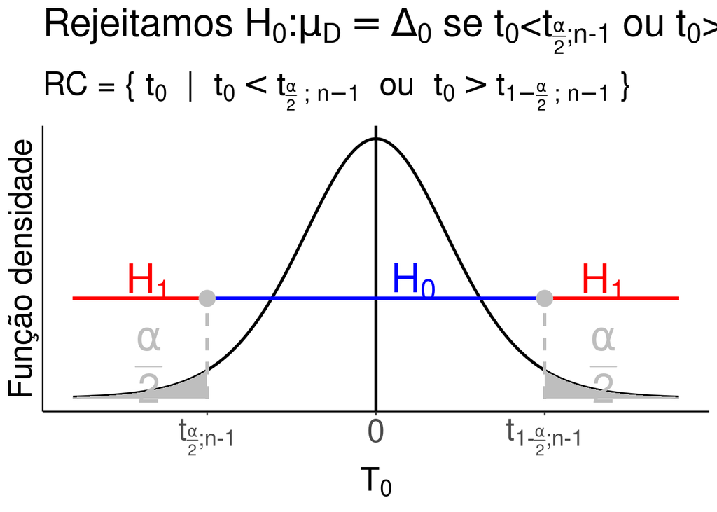

```r
gl <- 10
xmin <- -4
xmax <- 4
z <- seq(from = xmin, to= xmax, by = 0.001)
f <- dt(z, df = gl)
dados <- tibble(z=z, f=f)
a <- 0.05
lower <- qt(a / 2, df = gl)
upper <- qt(1 - a / 2, df = gl)

ggplot(dados)+
  geom_line(aes(x = z, y = f), color = "black", size = 1) +
  labs(x = TeX("$T_0$"), y = "Função densidade",
       title = TeX("Rejeitamos $H_0: \\mu_{D} = \\Delta_{0}$ se $t_0 < t_{\\frac{\\alpha}{2};n-1}$ ou $t_0 > t_{1-\\frac{\\alpha}{2};n-1}$"),
       subtitle = bquote("RC = {" ~ t[0] ~ " | " ~ t[0] < t[frac(alpha, 2)~';'~n-1] ~ " ou " ~ t[0] > t[1-frac(alpha, 2)~';'~n-1] ~ "}")) +
  scale_x_continuous(breaks = c(lower, 0, upper),
                     labels = c(TeX("$t_{\\frac{\\alpha}{2};n-1}$"), "0",
                                TeX("$t_{1- \\frac{\\alpha}{2}; n-1}$"))) +
  scale_y_continuous(breaks = NULL) +
  geom_ribbon(data = dplyr::filter(dados, z < lower),
              aes(x = z, y = f, ymin = 0, ymax = f),
              fill = "gray") +
  geom_ribbon(data = dplyr::filter(dados, z > upper),
              aes(x = z, y = f, ymin = 0, ymax = f),
              fill = "gray") +
  theme_classic() +
  theme(axis.title = element_text(size = 22.5),
        axis.text = element_text(size = 22.5),
        title = element_text(size = 22.5)) +
  geom_vline(xintercept = 0, color = "black", size = 1) +
  geom_segment(x = xmin, xend = lower, y = 0.15, yend =0.15, size = 1, color = "red") +
  geom_segment(x = upper, xend = xmax, y = 0.15, yend =0.15, size = 1, color = "red") +
  geom_segment(x = lower, xend = upper, y = 0.15, yend =0.15, size = 1, color = "blue") +
  geom_segment(x = lower, xend = lower, y = 0, yend = 0.15,
               linetype = "dashed", color = "gray", size = 1) +
  geom_segment(x = upper, xend = upper, y = 0, yend = 0.15,
               linetype = "dashed", color = "gray", size = 1) +
  geom_point(data = tibble(x = c(lower, upper), y = c(0.15, 0.15)),
             aes(x = x, y = y), size = 5,color  = "gray") +
  annotate("text", x = -3, y = 0.175, label = "H[1]",
           size = 10, color = "red", parse = T) +
  annotate("text", x = 3, y = 0.175, label = "H[1]",
           size = 10, color = "red", parse = T) +
  annotate("text", x = 0.5, y = 0.175, label = "H[0]",
           size = 10, color = "blue", parse = T) +
  annotate("text", x = -3, y = 0.05, label = "frac(alpha, 2)", parse = T,
           color = "gray", size = 10) +
  annotate("text", x = 3, y = 0.05, label = "frac(alpha, 2)", parse = T,
           color = "gray", size = 10)
```

```r
ggsave("../figures/paired-t-test-bilateral.png")
ggsave("../figures/paired-t-test-bilateral.pdf")
```

Example from Montgomery fot paired t-test.

```r
x1 <- c( 1.186,
  1.151,
  1.322,
  1.339,
  1.200,
  1.402,
  1.365,
  1.537,
  1.559
 )
x2 <- c( 1.061,
  0.992,
  1.063,
  1.062,
  1.065,
  1.178,
  1.037,
  1.086,
  1.052
 )

dados <- tibble(Vigas = str_c('Vigas ', seq_along(x1)),
                `Karlsruhe Method` = x1,
                `Lehigh Method` = x2, `Diferença d` = x1 - x2)

dados %>% xtable(caption = "Previsões de resistência para nove vigas de chapa de aço",
                 label = "tab:paired-t-test-bilateral",
                 digits = 2,
                 align = rep("c", ncol(dados) + 1)) %>%
  print.xtable(booktabs = T,
               include.rownames = F,
               format.args = list(decimal.mark = ","))
```

```
% latex table generated in R 4.1.0 by xtable 1.8-4 package
% Sun May 30 15:08:38 2021
\begin{table}[ht]
\centering
\begin{tabular}{cccc}
  \toprule
Vigas & Karlsruhe Method & Lehigh Method & Diferença d \\
  \midrule
Vigas 1 & 1,19 & 1,06 & 0,12 \\
  Vigas 2 & 1,15 & 0,99 & 0,16 \\
  Vigas 3 & 1,32 & 1,06 & 0,26 \\
  Vigas 4 & 1,34 & 1,06 & 0,28 \\
  Vigas 5 & 1,20 & 1,06 & 0,14 \\
  Vigas 6 & 1,40 & 1,18 & 0,22 \\
  Vigas 7 & 1,36 & 1,04 & 0,33 \\
  Vigas 8 & 1,54 & 1,09 & 0,45 \\
  Vigas 9 & 1,56 & 1,05 & 0,51 \\
   \bottomrule
\end{tabular}
\caption{Previsões de resistência para nove vigas de chapa de aço}
\label{tab:paired-t-test-bilateral}
\end{table}
```

```r
tab <- dados %>%
  summarise(d_bar = mean(`Karlsruhe Method`) - mean(`Lehigh Method`),
            s_D = sd(`Diferença d`),
            t0 = ((d_bar - 0) * sqrt(n())) / s_D)
```

Computing the sample size for paired t-test.

```r
samp_size_paired_t_test <- function(m_D, s_D, delta0 = 0, alpha = 0.05, power = 0.95){
  aux <- function(k){
    k %>%
      map_dbl(~ (1 -
                   pt(qt(1 - alpha / 2, df = .x - 1), df = .x - 1,
                      ncp = (m_D - delta0) * sqrt(.x) / s_D) +
                   pt(qt(alpha / 2, df = .x - 1), df = .x - 1,
                      ncp = (m_D - delta0) * sqrt(.x) / s_D)-
                   power)^2)
  }

  nlminb(4, aux, lower = 3, upper = Inf)$par %>% ceiling()
}

samp_size_paired_t_test(m_D = 0.3, s_D = 0.5, delta0 = 0, alpha = 0.05, power = 0.99)
```

```
[1] 54
```

### Graph for unilateral test ($H_1$ greater)

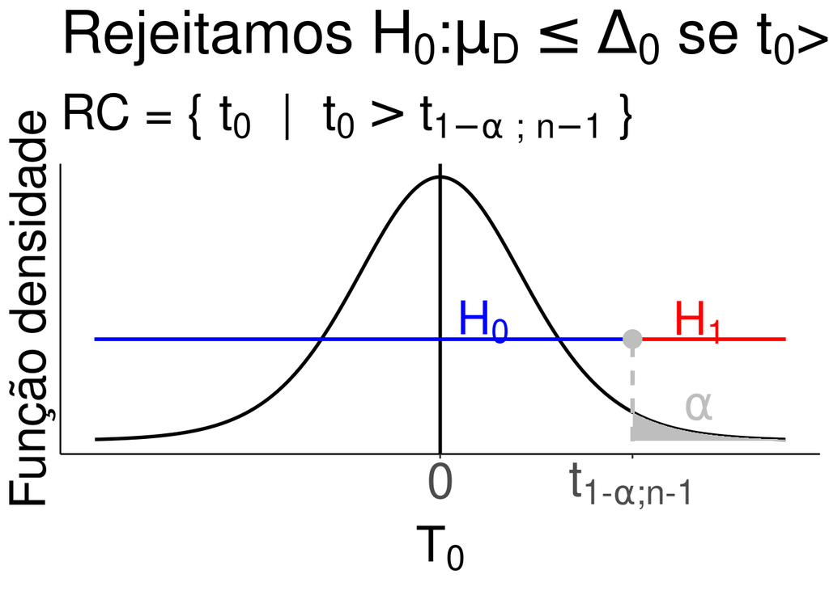

```r
gl <- 10
xmin <- -4
xmax <- 4
z <- seq(from = xmin, to= xmax, by = 0.001)
f <- dt(z, df = gl)
dados <- tibble(z=z, f=f)
a <- 0.05
lower <- qt(a / 2, df = gl)
upper <- qt(1 - a / 2, df = gl)

ggplot(dados)+
  geom_line(aes(x = z, y = f), color = "black", size = 1) +
  labs(x = TeX("$T_0$"), y = "Função densidade",
       title = TeX("Rejeitamos $H_0: \\mu_{D} \\leq \\Delta_{0}$ se $t_0 > t_{1-\\alpha;n-1}$"),
       subtitle = bquote("RC = {" ~ t[0] ~ " | " ~ t[0] > t[1-alpha~';'~n-1] ~ "}")) +
  scale_x_continuous(breaks = c(0, upper),
                     labels = c(0,TeX("$t_{1- \\alpha; n-1}$"))) +
  scale_y_continuous(breaks = NULL) +
  geom_ribbon(data = dplyr::filter(dados, z > upper),
              aes(x = z, y = f, ymin = 0, ymax = f),
              fill = "gray") +
  theme_classic() +
  theme(axis.title = element_text(size = 30),
        axis.text = element_text(size = 30),
        title = element_text(size = 30)) +
  geom_vline(xintercept = 0, color = "black", size = 1) +
  geom_segment(x = xmin, xend = upper, y = 0.15, yend =0.15, size = 1, color = "blue") +
  geom_segment(x = upper, xend = xmax, y = 0.15, yend =0.15, size = 1, color = "red") +
  geom_segment(x = upper, xend = upper, y = 0, yend = 0.15,
               linetype = "dashed", color = "gray", size = 1) +
  geom_point(data = tibble(x = c(upper), y = c(0.15)),
             aes(x = x, y = y), size = 5,color  = "gray") +
  annotate("text", x = 3, y = 0.175, label = "H[1]",
           size = 10, color = "red", parse = T) +
  annotate("text", x = 0.5, y = 0.175, label = "H[0]",
           size = 10, color = "blue", parse = T) +
  annotate("text", x = 3, y = 0.05, label = "alpha", parse = T,
           color = "gray", size = 10)
```

```r
ggsave("../figures/paired-t-test-h1-upper.png")
ggsave("../figures/paired-t-test-h1-upper.pdf")
```

Exemplo do livro.

```r
antes <- c( 265,
  240,
  258,
  295,
  251,
  245,
  287,
  314,
  260,
  279,
  283,
  240,
  238,
  225,
  247
 )
depois <- c( 229,
 231,
 227,
 240,
 238,
 241,
 234,
 256,
 247,
 239,
 246,
 218,
 219,
 226,
 233
)
dados <- tibble(Sujeito = str_c("Sujeito ", seq_along(antes)),
                Antes = antes, Depois = depois)

dados %>%
  xtable(caption = "Nível de colesterol.",
         label = "tab:col", digits = 0,
         align = rep("c", ncol(dados) + 1)) %>%
  print.xtable(include.rownames = F, booktabs = T,
               format.args = list(decimal.mark = ","))
```

```
% latex table generated in R 4.1.0 by xtable 1.8-4 package
% Sun May 30 15:08:39 2021
\begin{table}[ht]
\centering
\begin{tabular}{ccc}
  \toprule
Sujeito & Antes & Depois \\
  \midrule
Sujeito 1 & 265 & 229 \\
  Sujeito 2 & 240 & 231 \\
  Sujeito 3 & 258 & 227 \\
  Sujeito 4 & 295 & 240 \\
  Sujeito 5 & 251 & 238 \\
  Sujeito 6 & 245 & 241 \\
  Sujeito 7 & 287 & 234 \\
  Sujeito 8 & 314 & 256 \\
  Sujeito 9 & 260 & 247 \\
  Sujeito 10 & 279 & 239 \\
  Sujeito 11 & 283 & 246 \\
  Sujeito 12 & 240 & 218 \\
  Sujeito 13 & 238 & 219 \\
  Sujeito 14 & 225 & 226 \\
  Sujeito 15 & 247 & 233 \\
   \bottomrule
\end{tabular}
\caption{Nível de colesterol.}
\label{tab:col}
\end{table}
```

```r
tab <- dados %>%
  summarise(d_bar = mean(Antes) - mean(Depois),
            s_D = sd(Antes - Depois),
            t0 = (d_bar - 0) * sqrt(n()) / s_D)
```

Sample size.

```r
samp_size_paired_t_test <- function(m_D, s_D, delta0 = 0, alpha = 0.05, power = 0.95){
  aux <- function(k){
    k %>%
      map_dbl(~ (1 -
                   pt(qt(1 - alpha, df = .x - 1), df = .x - 1,
                      ncp = (m_D - delta0) * sqrt(.x) / s_D) -
                   power)^2)
  }

  nlminb(4, aux, lower = 3, upper = Inf)$par %>% ceiling()
}
samp_size_paired_t_test(m_D = 25, s_D = 15, delta0 = 0, alpha = 0.05, power = 0.99)
```

```
[1] 8
```

### Graph for unilateral test ($H_1$ lower)

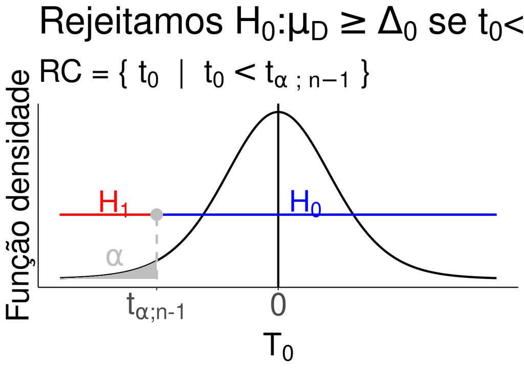

```r
gl <- 10
xmin <- -4
xmax <- 4
z <- seq(from = xmin, to= xmax, by = 0.001)
f <- dt(z, df = gl)
dados <- tibble(z=z, f=f)
a <- 0.05
lower <- qt(a / 2, df = gl)
upper <- qt(1 - a / 2, df = gl)

ggplot(dados)+
  geom_line(aes(x = z, y = f), color = "black", size = 1) +
  labs(x = TeX("$T_0$"), y = "Função densidade",
       title = TeX("Rejeitamos $H_0: \\mu_{D} \\geq \\Delta_{0}$ se $t_0 < t_{\\alpha;n-1}$"),
       subtitle = bquote("RC = {" ~ t[0] ~ " | " ~ t[0] < t[alpha~';'~n-1] ~ "}")) +
  scale_x_continuous(breaks = c(lower, 0),
                     labels = c(TeX("$t_{\\alpha; n-1}$"), 0)) +
  scale_y_continuous(breaks = NULL) +
  geom_ribbon(data = dplyr::filter(dados, z < lower),
              aes(x = z, y = f, ymin = 0, ymax = f),
              fill = "gray") +
  theme_classic() +
  theme(axis.title = element_text(size = 30),
        axis.text = element_text(size = 30),
        title = element_text(size = 30)) +
  geom_vline(xintercept = 0, color = "black", size = 1) +
  geom_segment(x = xmin, xend = lower, y = 0.15, yend =0.15, size = 1, color = "red") +
  geom_segment(x = lower, xend = xmax, y = 0.15, yend =0.15, size = 1, color = "blue") +
  geom_segment(x = lower, xend = lower, y = 0, yend = 0.15,
               linetype = "dashed", color = "gray", size = 1) +
  geom_point(data = tibble(x = c(lower), y = c(0.15)),
             aes(x = x, y = y), size = 5,color  = "gray") +
  annotate("text", x = -3, y = 0.175, label = "H[1]",
           size = 10, color = "red", parse = T) +
  annotate("text", x = 0.5, y = 0.175, label = "H[0]",
           size = 10, color = "blue", parse = T) +
  annotate("text", x = -3, y = 0.05, label = "alpha", parse = T,
           color = "gray", size = 10)
```

```r
ggsave("../figures/paired-t-test-h1-lower.png")
ggsave("../figures/paired-t-test-h1-lower.pdf")
```

Simulated example.

```r
set.seed(1235813)
rho <- 0.95
s2_D <- 10
mu_1 <- 15
mu_2 <- 20
s2 <- s2_D / (2 * (1 + rho))
covi <- s2 * rho
n <- 20

matriz <- mvtnorm::rmvnorm(n, mean = c(mu_1, mu_2),
                           sigma = cbind(c(s2, covi), c(covi, s2)))
dados <- tibble(x1 = matriz[,1], x2 = matriz[,2])

tab <- dados %>%
  summarise(m1 = mean(x1), m2 = mean(x2), s_D = sd(x1 - x2))
```

Sample size.

```r
samp_size_paired_t_test <- function(m_D, s_D, delta0 = 0, alpha = 0.05, power = 0.95){
  aux <- function(k){
    k %>%
      map_dbl(~ (pt(qt(alpha, df = .x - 1), df = .x - 1,
                      ncp = (m_D - delta0) * sqrt(.x) / s_D) -
                   power)^2)
  }

  nlminb(4, aux, lower = 3, upper = Inf)$par %>% ceiling()
}
samp_size_paired_t_test(m_D = -5, s_D = 20, delta0 = 0, alpha = 0.05, power = 0.99)
```

```
[1] 254
```

## Comparison of two proportions

### Bilateral

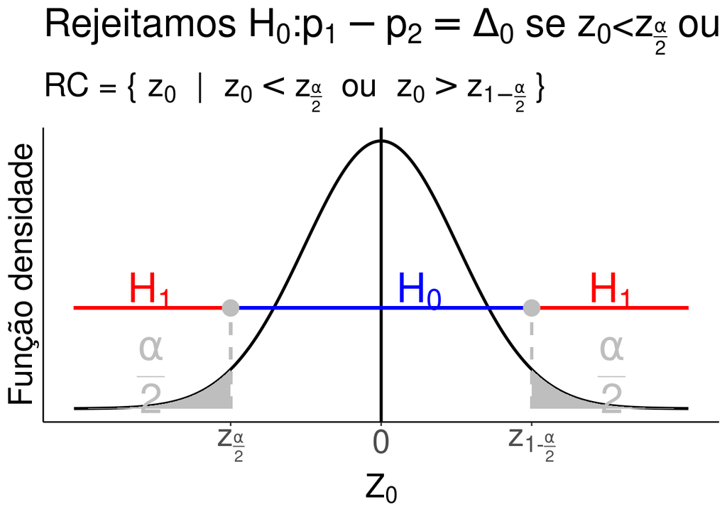

```r
xmin <- -4
xmax <- 4
z <- seq(from = xmin, to= xmax, by = 0.001)
f <- dnorm(z)
dados <- tibble(z=z, f=f)
a <- 0.05
lower <- qnorm(a / 2)
upper <- qnorm(1 - a / 2)

ggplot(dados)+
  geom_line(aes(x = z, y = f), color = "black", size = 1) +
  labs(x = TeX("$Z_0$"), y = "Função densidade",
       title = TeX("Rejeitamos $H_0: p_1 - p_2 = \\Delta_{0}$ se $z_0 < z_{\\frac{\\alpha}{2}}$ ou $z_0 > z_{1-\\frac{\\alpha}{2}}$"),
       subtitle = bquote("RC = {" ~ z[0] ~ " | " ~ z[0] < z[frac(alpha, 2)] ~ " ou " ~ z[0] > z[1-frac(alpha, 2)] ~ "}")) +
  scale_x_continuous(breaks = c(lower, 0, upper),
                     labels = c(TeX("$z_{\\frac{\\alpha}{2}}$"), "0",
                                TeX("$z_{1- \\frac{\\alpha}{2}}$"))) +
  scale_y_continuous(breaks = NULL) +
  geom_ribbon(data = dplyr::filter(dados, z < lower),
              aes(x = z, y = f, ymin = 0, ymax = f),
              fill = "gray") +
  geom_ribbon(data = dplyr::filter(dados, z > upper),
              aes(x = z, y = f, ymin = 0, ymax = f),
              fill = "gray") +
  theme_classic() +
  theme(axis.title = element_text(size = 22.5),
        axis.text = element_text(size = 22.5),
        title = element_text(size = 22.5)) +
  geom_vline(xintercept = 0, color = "black", size = 1) +
  geom_segment(x = xmin, xend = lower, y = 0.15, yend =0.15, size = 1, color = "red") +
  geom_segment(x = upper, xend = xmax, y = 0.15, yend =0.15, size = 1, color = "red") +
  geom_segment(x = lower, xend = upper, y = 0.15, yend =0.15, size = 1, color = "blue") +
  geom_segment(x = lower, xend = lower, y = 0, yend = 0.15,
               linetype = "dashed", color = "gray", size = 1) +
  geom_segment(x = upper, xend = upper, y = 0, yend = 0.15,
               linetype = "dashed", color = "gray", size = 1) +
  geom_point(data = tibble(x = c(lower, upper), y = c(0.15, 0.15)),
             aes(x = x, y = y), size = 5,color  = "gray") +
  annotate("text", x = -3, y = 0.175, label = "H[1]",
           size = 10, color = "red", parse = T) +
  annotate("text", x = 3, y = 0.175, label = "H[1]",
           size = 10, color = "red", parse = T) +
  annotate("text", x = 0.5, y = 0.175, label = "H[0]",
           size = 10, color = "blue", parse = T) +
  annotate("text", x = -3, y = 0.05, label = "frac(alpha, 2)", parse = T,
           color = "gray", size = 10) +
  annotate("text", x = 3, y = 0.05, label = "frac(alpha, 2)", parse = T,
           color = "gray", size = 10)
```

```r
ggsave("../figures/two-proportion-bilateral.png")
ggsave("../figures/two-proportion-bilateral.pdf")
```

### Unilateral ($H_1$ greater)

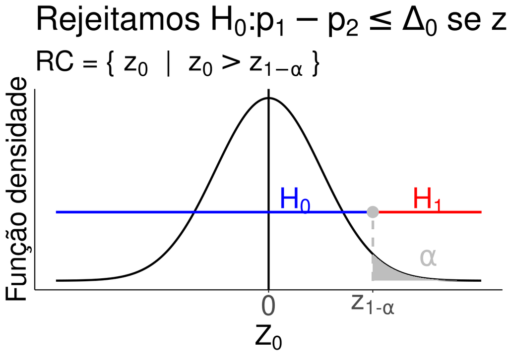

```r
xmin <- -4
xmax <- 4
z <- seq(from = xmin, to= xmax, by = 0.001)
f <- dnorm(z)
dados <- tibble(z=z, f=f)
a <- 0.05
lower <- qnorm(a / 2)
upper <- qnorm(1 - a / 2)

ggplot(dados)+
  geom_line(aes(x = z, y = f), color = "black", size = 1) +
  labs(x = TeX("$Z_0$"), y = "Função densidade",
       title = TeX("Rejeitamos $H_0: p_1 - p_2 \\leq \\Delta_{0}$ se $z_0 > z_{1-\\alpha}$"),
       subtitle = bquote("RC = {" ~ z[0] ~ " | " ~ z[0] > z[1-alpha] ~ "}")) +
  scale_x_continuous(breaks = c(0, upper),
                     labels = c(0,TeX("$z_{1- \\alpha}$"))) +
  scale_y_continuous(breaks = NULL) +
  geom_ribbon(data = dplyr::filter(dados, z > upper),
              aes(x = z, y = f, ymin = 0, ymax = f),
              fill = "gray") +
  theme_classic() +
  theme(axis.title = element_text(size = 27.5),
        axis.text = element_text(size = 27.5),
        title = element_text(size = 27.5)) +
  geom_vline(xintercept = 0, color = "black", size = 1) +
  geom_segment(x = xmin, xend = upper, y = 0.15, yend =0.15, size = 1, color = "blue") +
  geom_segment(x = upper, xend = xmax, y = 0.15, yend =0.15, size = 1, color = "red") +
  geom_segment(x = upper, xend = upper, y = 0, yend = 0.15,
               linetype = "dashed", color = "gray", size = 1) +
  geom_point(data = tibble(x = c(upper), y = c(0.15)),
             aes(x = x, y = y), size = 5,color  = "gray") +
  annotate("text", x = 3, y = 0.175, label = "H[1]",
           size = 10, color = "red", parse = T) +
  annotate("text", x = 0.5, y = 0.175, label = "H[0]",
           size = 10, color = "blue", parse = T) +
  annotate("text", x = 3, y = 0.05, label = "alpha", parse = T,
           color = "gray", size = 10)
```

```r
ggsave("../figures/two-proportion-h1-upper.png")
ggsave("../figures/two-proportion-h1-upper.pdf")
```

### Unilateral ($H_1$ less)

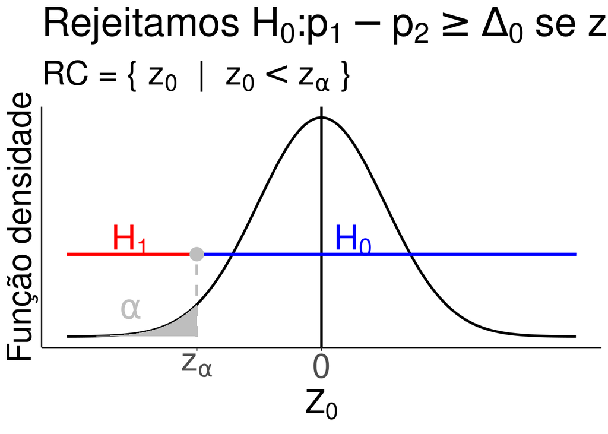

```r
xmin <- -4
xmax <- 4
z <- seq(from = xmin, to= xmax, by = 0.001)
f <- dnorm(z)
dados <- tibble(z=z, f=f)
a <- 0.05
lower <- qnorm(a / 2)
upper <- qnorm(1 - a / 2)

ggplot(dados)+
  geom_line(aes(x = z, y = f), color = "black", size = 1) +
  labs(x = TeX("$Z_0$"), y = "Função densidade",
       title = TeX("Rejeitamos $H_0: p_1 - p_2 \\geq \\Delta_{0}$ se $z_0 < z_{\\alpha}$"),
       subtitle = bquote("RC = {" ~ z[0] ~ " | " ~ z[0] < z[alpha] ~ "}")) +
  scale_x_continuous(breaks = c(lower, 0),
                     labels = c(TeX("$z_{\\alpha}$"), 0)) +
  scale_y_continuous(breaks = NULL) +
  geom_ribbon(data = dplyr::filter(dados, z < lower),
              aes(x = z, y = f, ymin = 0, ymax = f),
              fill = "gray") +
  theme_classic() +
  theme(axis.title = element_text(size = 27.5),
        axis.text = element_text(size = 27.5),
        title = element_text(size = 27.5)) +
  geom_vline(xintercept = 0, color = "black", size = 1) +
  geom_segment(x = xmin, xend = lower, y = 0.15, yend =0.15, size = 1, color = "red") +
  geom_segment(x = lower, xend = xmax, y = 0.15, yend =0.15, size = 1, color = "blue") +
  geom_segment(x = lower, xend = lower, y = 0, yend = 0.15,
               linetype = "dashed", color = "gray", size = 1) +
  geom_point(data = tibble(x = c(lower), y = c(0.15)),
             aes(x = x, y = y), size = 5,color  = "gray") +
  annotate("text", x = -3, y = 0.175, label = "H[1]",
           size = 10, color = "red", parse = T) +
  annotate("text", x = 0.5, y = 0.175, label = "H[0]",
           size = 10, color = "blue", parse = T) +
  annotate("text", x = -3, y = 0.05, label = "alpha", parse = T,
           color = "gray", size = 10)
```

```r
ggsave("../figures/two-proportion-h1-lower.png")
ggsave("../figures/two-proportion-h1-lower.pdf")
```

Simulated example.

```r
set.seed(1235813)
p1 <- 0.5
p2 <- 0.2
n1 <- 250
n2 <- 300
x1 <- rbinom(n1, 1, p1)
x2 <- rbinom(n2, 1, p2)

sum(x1)
```

```
[1] 147
```

```r
sum(x2)
```

```
[1] 52
```

# Association test

## contingency tables

### Ilustrative example for independent qualitative variables

There is association between two variables.

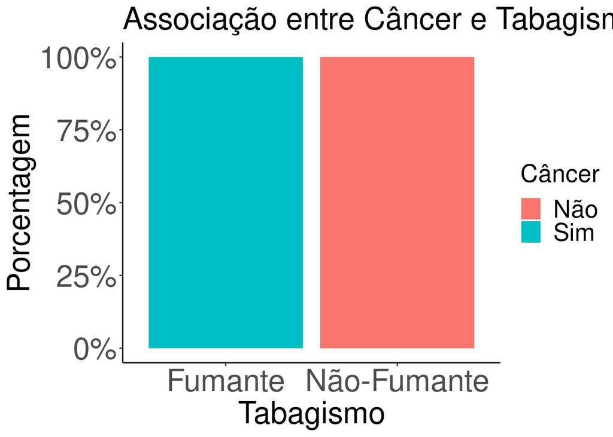

```r
tab <- tibble(tabagismo = c("Não-Fumante","Fumante"),
              `Não` = c(200,0),
              Sim = c(0,100)) %>%
  gather(`Não`,Sim, key = "Câncer", value = "Freq") %>%
  group_by(`Câncer`) %>%
  mutate(freq_rel = 100*Freq / sum(Freq))


ggplot(tab) +
  geom_bar(aes(x = tabagismo,y=freq_rel,fill=`Câncer`),
           stat = "identity", position = "fill")+
  xlab("Tabagismo")+
  ylab("Porcentagem")+
  ggtitle("Associação entre Câncer e Tabagismo.")+
  scale_y_continuous(breaks = c(0,.25,.50,.75,1),
                     labels = str_c(c(0,25,50,75,100), "%"))  +
  theme_classic() +
  theme(axis.text = element_text(size = 25),
        axis.title = element_text(size = 25),
        plot.title = element_text(size = 25),
        legend.title = element_text(size = 20),
        legend.text = element_text(size = 20))
```

```r
ggsave('../figures/associacao.png')
ggsave('../figures/associacao.pdf')
```

There is no association between two variables.

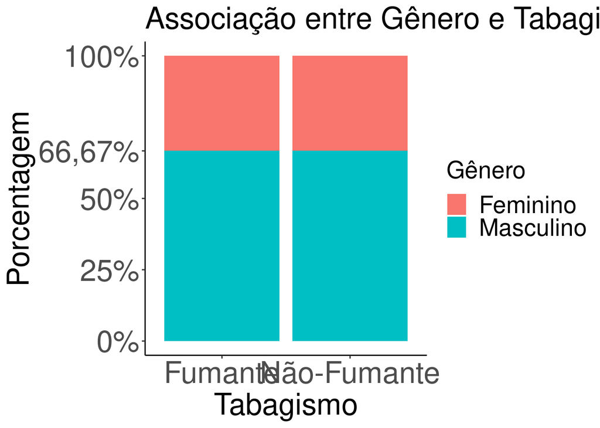

```r
tab <- tibble(`Gênero` = c("Masculino","Feminino"),
              `Não-Fumante` = c(80,40),
              Fumante = c(120,60)) %>%
  gather(`Não-Fumante`, Fumante, key = "tabagismo", value = "Freq") %>%
  group_by(tabagismo) %>%
  mutate(freq_rel = 100*Freq / sum(Freq))

ggplot(tab) +
  geom_bar(aes(x = tabagismo,y=freq_rel,fill=`Gênero`),
           stat = "identity", position = "fill")+
  xlab("Tabagismo")+
  ylab("Porcentagem")+
  ggtitle("Associação entre Gênero e Tabagismo.")+
  scale_y_continuous(breaks = c(0,.25,.50, 0.6667,1),
                     labels = str_c(c(0,25,50,"66,67",100), "%"))  +
  theme_classic() +
  theme(axis.text = element_text(size = 25),
        axis.title = element_text(size = 25),
        plot.title = element_text(size = 25),
        legend.title = element_text(size = 20),
        legend.text = element_text(size = 20))
```

```r
ggsave('../figures/nao_associacao.png')
ggsave('../figures/nao_associacao.pdf')
```

Real example.

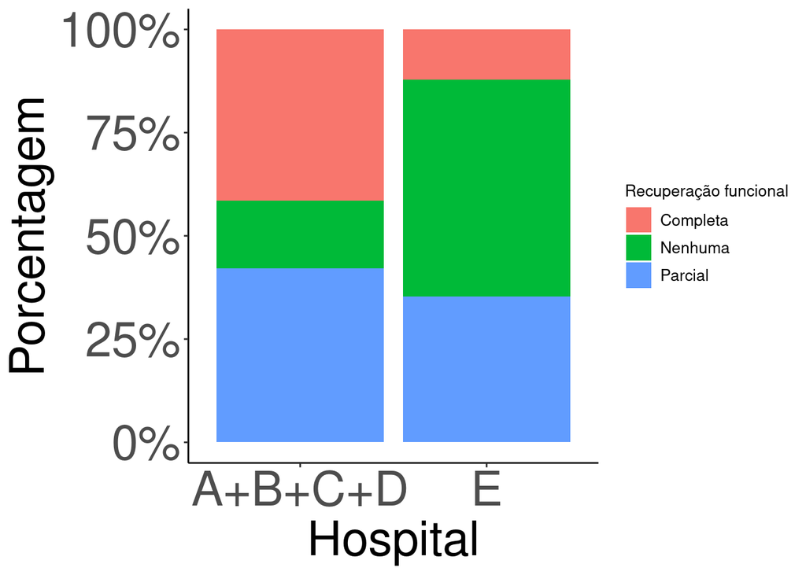

```r
tab <- tibble(`Recuperação funcional`  = c("Nenhuma","Parcial", "Completa"),
              `A+B+C+D` = c(47, 120, 118),
              E = c(43, 29, 10)) %>%
  gather(`A+B+C+D`, E, key = "hospital", value = "Freq") %>%
  group_by(hospital) %>%
  mutate(freq_rel = 100*Freq / sum(Freq))

ggplot(tab) +
  geom_bar(aes(x = hospital,y=freq_rel,fill=`Recuperação funcional`),
           stat = "identity", position = "fill")+
  xlab("Hospital")+
  ylab("Porcentagem")+
  # ggtitle("Associação entre Hospital e Recuperação funcional.")+
  scale_y_continuous(breaks = c(0,.25,.50,.75,1),
                     labels = str_c(c(0,25,50,75,100), "%"))  +
  theme_classic() +
  theme(axis.text = element_text(size = 30),
        axis.title = element_text(size = 30),
        plot.title = element_text(size = 20),
        legend.title = element_text(size = 10),
        legend.text = element_text(size = 10))
```

```r
ggsave('../figures/associacao_moderada.png')
ggsave('../figures/associacao_moderada.pdf')
m <- rbind(c(47, 120, 118),
           c(43, 29, 10))
colnames(m) <- c("Nenhuma","Parcial", "Completa")
rownames(m) <- c("A+B+C+D", "E")
m_prop <- m / sum(m)
pwr::ES.w2(m_prop)
```

```
[1] 0.3685303
```

## test on Pearson’s correlation

### Bilateral testing

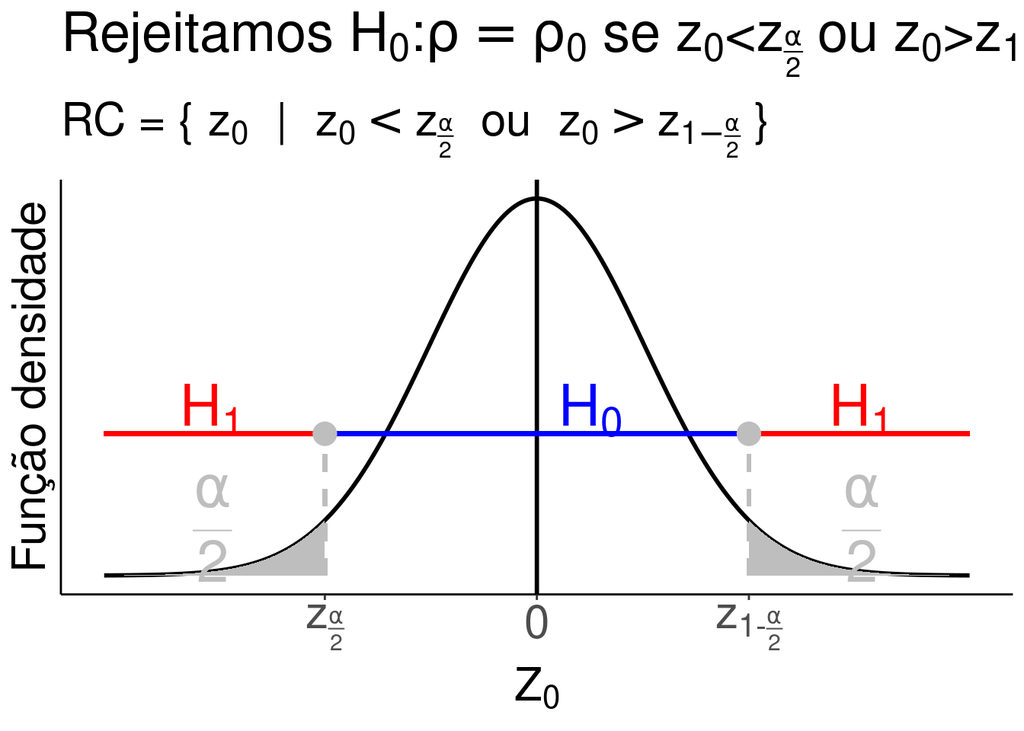

```r
xmin <- -4
xmax <- 4
z <- seq(from = xmin, to= xmax, by = 0.001)
f <- dnorm(z)
dados <- tibble(z=z, f=f)
a <- 0.05
lower <- qnorm(a / 2)
upper <- qnorm(1 - a / 2)

ggplot(dados)+
  geom_line(aes(x = z, y = f), color = "black", size = 1) +
  labs(x = TeX("$Z_0$"), y = "Função densidade",
       title = TeX("Rejeitamos $H_0: \\rho = \\rho_{0}$ se $z_0 < z_{\\frac{\\alpha}{2}}$ ou $z_0 > z_{1-\\frac{\\alpha}{2}}$"),
       subtitle = bquote("RC = {" ~ z[0] ~ " | " ~ z[0] < z[frac(alpha, 2)] ~ " ou " ~ z[0] > z[1-frac(alpha, 2)] ~ "}")) +
  scale_x_continuous(breaks = c(lower, 0, upper),
                     labels = c(TeX("$z_{\\frac{\\alpha}{2}}$"), "0",
                                TeX("$z_{1- \\frac{\\alpha}{2}}$"))) +
  scale_y_continuous(breaks = NULL) +
  geom_ribbon(data = dplyr::filter(dados, z < lower),
              aes(x = z, y = f, ymin = 0, ymax = f),
              fill = "gray") +
  geom_ribbon(data = dplyr::filter(dados, z > upper),
              aes(x = z, y = f, ymin = 0, ymax = f),
              fill = "gray") +
  theme_classic() +
  theme(axis.title = element_text(size = 22.5),
        axis.text = element_text(size = 22.5),
        title = element_text(size = 22.5)) +
  geom_vline(xintercept = 0, color = "black", size = 1) +
  geom_segment(x = xmin, xend = lower, y = 0.15, yend =0.15, size = 1, color = "red") +
  geom_segment(x = upper, xend = xmax, y = 0.15, yend =0.15, size = 1, color = "red") +
  geom_segment(x = lower, xend = upper, y = 0.15, yend =0.15, size = 1, color = "blue") +
  geom_segment(x = lower, xend = lower, y = 0, yend = 0.15,
               linetype = "dashed", color = "gray", size = 1) +
  geom_segment(x = upper, xend = upper, y = 0, yend = 0.15,
               linetype = "dashed", color = "gray", size = 1) +
  geom_point(data = tibble(x = c(lower, upper), y = c(0.15, 0.15)),
             aes(x = x, y = y), size = 5,color  = "gray") +
  annotate("text", x = -3, y = 0.175, label = "H[1]",
           size = 10, color = "red", parse = T) +
  annotate("text", x = 3, y = 0.175, label = "H[1]",
           size = 10, color = "red", parse = T) +
  annotate("text", x = 0.5, y = 0.175, label = "H[0]",
           size = 10, color = "blue", parse = T) +
  annotate("text", x = -3, y = 0.05, label = "frac(alpha, 2)", parse = T,
           color = "gray", size = 10) +
  annotate("text", x = 3, y = 0.05, label = "frac(alpha, 2)", parse = T,
           color = "gray", size = 10)
```

```r
ggsave("../figures/z-fisher-cor-bilateral.png")
ggsave("../figures/z-fisher-cor-bilateral.pdf")
```

### Unilateral ($H_1$ greater)

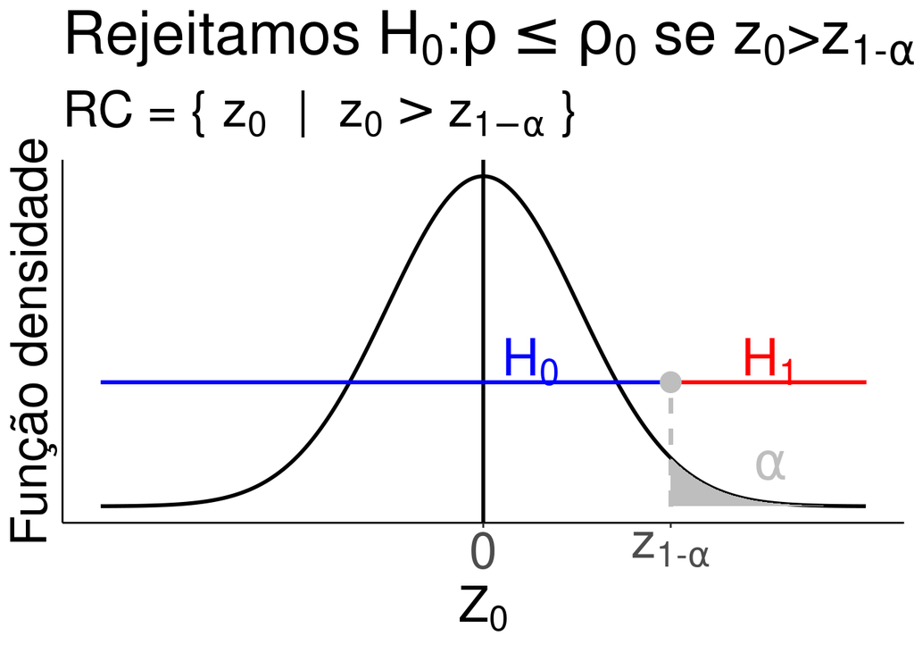

```r
xmin <- -4
xmax <- 4
z <- seq(from = xmin, to= xmax, by = 0.001)
f <- dnorm(z)
dados <- tibble(z=z, f=f)
a <- 0.05
lower <- qnorm(a / 2)
upper <- qnorm(1 - a / 2)

ggplot(dados)+
  geom_line(aes(x = z, y = f), color = "black", size = 1) +
  labs(x = TeX("$Z_0$"), y = "Função densidade",
       title = TeX("Rejeitamos $H_0: \\rho \\leq \\rho_{0}$ se $z_0 > z_{1-\\alpha}$"),
       subtitle = bquote("RC = {" ~ z[0] ~ " | " ~ z[0] > z[1-alpha] ~ "}")) +
  scale_x_continuous(breaks = c(0, upper),
                     labels = c(0,TeX("$z_{1- \\alpha}$"))) +
  scale_y_continuous(breaks = NULL) +
  geom_ribbon(data = dplyr::filter(dados, z > upper),
              aes(x = z, y = f, ymin = 0, ymax = f),
              fill = "gray") +
  theme_classic() +
  theme(axis.title = element_text(size = 27.5),
        axis.text = element_text(size = 27.5),
        title = element_text(size = 27.5)) +
  geom_vline(xintercept = 0, color = "black", size = 1) +
  geom_segment(x = xmin, xend = upper, y = 0.15, yend =0.15, size = 1, color = "blue") +
  geom_segment(x = upper, xend = xmax, y = 0.15, yend =0.15, size = 1, color = "red") +
  geom_segment(x = upper, xend = upper, y = 0, yend = 0.15,
               linetype = "dashed", color = "gray", size = 1) +
  geom_point(data = tibble(x = c(upper), y = c(0.15)),
             aes(x = x, y = y), size = 5,color  = "gray") +
  annotate("text", x = 3, y = 0.175, label = "H[1]",
           size = 10, color = "red", parse = T) +
  annotate("text", x = 0.5, y = 0.175, label = "H[0]",
           size = 10, color = "blue", parse = T) +
  annotate("text", x = 3, y = 0.05, label = "alpha", parse = T,
           color = "gray", size = 10)
```

```r
ggsave("../figures/z-fisher-cor-h1-upper.png")
ggsave("../figures/z-fisher-cor-h1-upper.pdf")
```

### Unilateral ($H_1$ less)

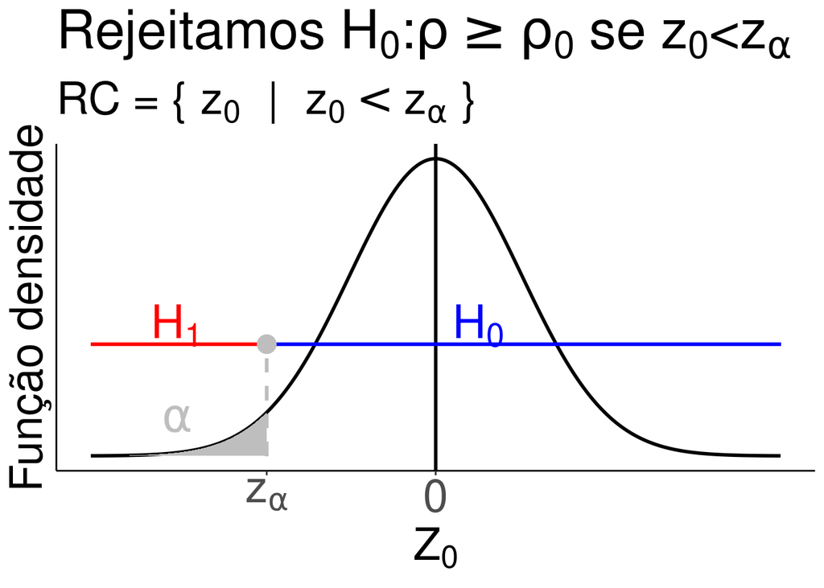

```r
xmin <- -4
xmax <- 4
z <- seq(from = xmin, to= xmax, by = 0.001)
f <- dnorm(z)
dados <- tibble(z=z, f=f)
a <- 0.05
lower <- qnorm(a / 2)
upper <- qnorm(1 - a / 2)

ggplot(dados)+
  geom_line(aes(x = z, y = f), color = "black", size = 1) +
  labs(x = TeX("$Z_0$"), y = "Função densidade",
       title = TeX("Rejeitamos $H_0: \\rho \\geq \\rho_{0}$ se $z_0 < z_{\\alpha}$"),
       subtitle = bquote("RC = {" ~ z[0] ~ " | " ~ z[0] < z[alpha] ~ "}")) +
  scale_x_continuous(breaks = c(lower, 0),
                     labels = c(TeX("$z_{\\alpha}$"), 0)) +
  scale_y_continuous(breaks = NULL) +
  geom_ribbon(data = dplyr::filter(dados, z < lower),
              aes(x = z, y = f, ymin = 0, ymax = f),
              fill = "gray") +
  theme_classic() +
  theme(axis.title = element_text(size = 27.5),
        axis.text = element_text(size = 27.5),
        title = element_text(size = 27.5)) +
  geom_vline(xintercept = 0, color = "black", size = 1) +
  geom_segment(x = xmin, xend = lower, y = 0.15, yend =0.15, size = 1, color = "red") +
  geom_segment(x = lower, xend = xmax, y = 0.15, yend =0.15, size = 1, color = "blue") +
  geom_segment(x = lower, xend = lower, y = 0, yend = 0.15,
               linetype = "dashed", color = "gray", size = 1) +
  geom_point(data = tibble(x = c(lower), y = c(0.15)),
             aes(x = x, y = y), size = 5,color  = "gray") +
  annotate("text", x = -3, y = 0.175, label = "H[1]",
           size = 10, color = "red", parse = T) +
  annotate("text", x = 0.5, y = 0.175, label = "H[0]",
           size = 10, color = "blue", parse = T) +
  annotate("text", x = -3, y = 0.05, label = "alpha", parse = T,
           color = "gray", size = 10)
```

```r
ggsave("../figures/z-fisher-cor-h1-lower.png")
ggsave("../figures/z-fisher-cor-h1-lower.pdf")
```

Below we simulate a normal example.

```r
set.seed(1235813)
n <- 1000
m <- mvtnorm::rmvnorm(n, mean = c(0, 2), sigma = rbind(c(1, -0.99), c(-0.99, 1))) %>%
  round(2)

tab <- tibble(x = m[,1], y=m[,2]) %>%
  summarise(
    s_x = sum(x),
    s_y = sum(y),
    s_x2 = sum(x^2),
    s_y2 = sum(y^2),
    s_xy = sum(x * y),
    n = n(),
    alpha = 0.05,
    `Decisão` = NA,
    `valor-p` = NA,
    `Z_0` = NA
  )

tab %>% xtable(caption = "Algumas informações do experimento",
               label = "tab:experimento-test-rho",
               align = rep("c", ncol(tab)+1),
               digits = 2) %>%
  print.xtable(
    booktabs = T,
    include.rownames = F,
    format.args = list(decimal.mark = ",")
  )
```

```
% latex table generated in R 4.1.0 by xtable 1.8-4 package
% Sun May 30 15:08:51 2021
\begin{table}[ht]
\centering
\begin{tabular}{cccccccccc}
  \toprule
s\_x & s\_y & s\_x2 & s\_y2 & s\_xy & n & alpha & Decisão & valor-p & Z\_0 \\
  \midrule
-0,49 & 2004,01 & 942,57 & 4960,45 & -934,66 & 1000 & 0,05 &  &  &  \\
   \bottomrule
\end{tabular}
\caption{Algumas informações do experimento}
\label{tab:experimento-test-rho}
\end{table}
```